# Home Credit Default Risk (HCDR)-Predicting Borrower Behavior-Phase3

## Dataset

### Background on the dataset

Home Credit is a consumer finance provider which focuses mainly on providing financial needs to customers with little or no credit history. Founded in 1999, Home Credit has branches internationally and spread across over 9 countries. It offers financial needs to the customers such as point of sale loans, cash loans and loans for products through online and physical distribution network. Generally, customers start with POS loans and satisfied customers adopt themselves to entire business model.

Its main aim is to:

- Focus on mass-retail lending with innovative financial methods.
- Fulfill client’s dreams and ambitions in a financially responsible manner.
- Provide long term and stable employment opportunities to the employers.
- Increase the standard of living through economic development supporting domestic consumption.

It offers retail banking services such as current and deposit accounts in countries where it has banking license. It focuses on customer retention by offering cross-selling opportunities across its product base.

### Data files overview

**bureau.csv**: This data file contains information regarding the borrower’s previous credit which was borrowed from other financial institutions and was reported to the Credit Bureau. It contains every detail of the number of credits the client previously had in the Credit Bureau before applying to loan at the Home Credit Group.

**bureau_balance.csv**: This dataset has information of borrower’s monthly credits in the previous credits. Every row in the data represents the history of previous credit reported to the Credit Bureau for every month.

**POS_CASH_balance.csv**: This data file contains monthly balance snapshots of cash loans that borrower had with Home Credit and previous point of sales. Each row has each month of history of every previous credit in Home Credit.

**credit_card_balance.csv**: This data file contains the snapshots of the history of credit cards that the borrower has with the Home credit. Each row has each month of history of every previous credit card in Home Credit.

**previous_application.csv**: This data file has all the applications that the borrower had applied for in the past.

**installments_payments.csv**: This data file has the history of the repayment that has been done for the disbursed amount in Home Credit. It has one row for every repayment that has been done and also the missed ones.

**HomeCredit_columns_description.csv**: This data file has the information about the columns in the other data files given.

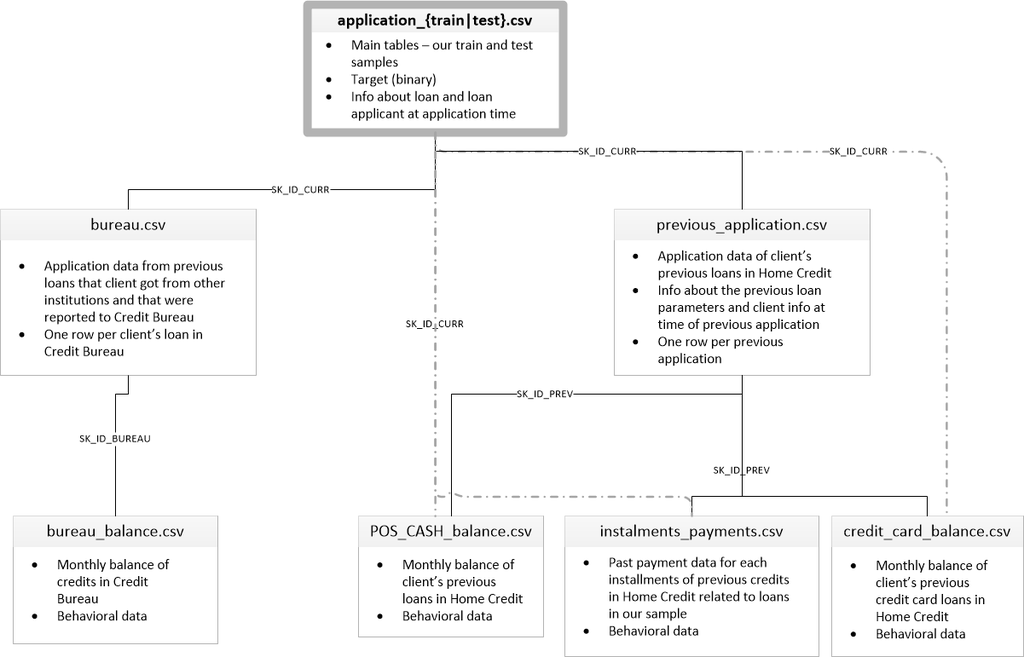

### Data Dictionary

`HomeCredit_columns_description.csv` is a data dictionary of this dataset

[figure not shown]

### Application train

- **application_train:** the main training and testing data with information about each loan application at Home Credit. Every loan has its own row and is identified by the feature SK_ID_CURR. The training application data comes with the TARGET indicating **0: the loan was repaid** or **1: the loan was not repaid**. The target variable defines if the client had payment difficulties meaning he/she had late payment more than X days on at least one of the first Y installments of the loan. Such case is marked as 1 while other all other cases as 0.

```python
import pandas as pd
application_train = pd.read_csv('../input/application_train.csv')
print(app_train_data.shape)
app_train_data.describe()
```

```
(307511, 122)
```

|  | SK_ID_CURR | TARGET | CNT_CHILDREN | AMT_INCOME_TOTAL | AMT_CREDIT | AMT_ANNUITY | AMT_GOODS_PRICE | REGION_POPULATION_RELATIVE | DAYS_BIRTH | DAYS_EMPLOYED | ... | FLAG_DOCUMENT_18 | FLAG_DOCUMENT_19 | FLAG_DOCUMENT_20 | FLAG_DOCUMENT_21 | AMT_REQ_CREDIT_BUREAU_HOUR | AMT_REQ_CREDIT_BUREAU_DAY | AMT_REQ_CREDIT_BUREAU_WEEK | AMT_REQ_CREDIT_BUREAU_MON | AMT_REQ_CREDIT_BUREAU_QRT | AMT_REQ_CREDIT_BUREAU_YEAR |
| --- | --- | --- | --- | --- | --- | --- | --- | --- | --- | --- | --- | --- | --- | --- | --- | --- | --- | --- | --- | --- | --- |
| count | 307511.000000 | 307511.000000 | 307511.000000 | 3.075110e+05 | 3.075110e+05 | 307499.000000 | 3.072330e+05 | 307511.000000 | 307511.000000 | 307511.000000 | ... | 307511.000000 | 307511.000000 | 307511.000000 | 307511.000000 | 265992.000000 | 265992.000000 | 265992.000000 | 265992.000000 | 265992.000000 | 265992.000000 |
| mean | 278180.518577 | 0.080729 | 0.417052 | 1.687979e+05 | 5.990260e+05 | 27108.573909 | 5.383962e+05 | 0.020868 | -16036.995067 | 63815.045904 | ... | 0.008130 | 0.000595 | 0.000507 | 0.000335 | 0.006402 | 0.007000 | 0.034362 | 0.267395 | 0.265474 | 1.899974 |
| std | 102790.175348 | 0.272419 | 0.722121 | 2.371231e+05 | 4.024908e+05 | 14493.737315 | 3.694465e+05 | 0.013831 | 4363.988632 | 141275.766519 | ... | 0.089798 | 0.024387 | 0.022518 | 0.018299 | 0.083849 | 0.110757 | 0.204685 | 0.916002 | 0.794056 | 1.869295 |
| min | 100002.000000 | 0.000000 | 0.000000 | 2.565000e+04 | 4.500000e+04 | 1615.500000 | 4.050000e+04 | 0.000290 | -25229.000000 | -17912.000000 | ... | 0.000000 | 0.000000 | 0.000000 | 0.000000 | 0.000000 | 0.000000 | 0.000000 | 0.000000 | 0.000000 | 0.000000 |
| 25% | 189145.500000 | 0.000000 | 0.000000 | 1.125000e+05 | 2.700000e+05 | 16524.000000 | 2.385000e+05 | 0.010006 | -19682.000000 | -2760.000000 | ... | 0.000000 | 0.000000 | 0.000000 | 0.000000 | 0.000000 | 0.000000 | 0.000000 | 0.000000 | 0.000000 | 0.000000 |
| 50% | 278202.000000 | 0.000000 | 0.000000 | 1.471500e+05 | 5.135310e+05 | 24903.000000 | 4.500000e+05 | 0.018850 | -15750.000000 | -1213.000000 | ... | 0.000000 | 0.000000 | 0.000000 | 0.000000 | 0.000000 | 0.000000 | 0.000000 | 0.000000 | 0.000000 | 1.000000 |
| 75% | 367142.500000 | 0.000000 | 1.000000 | 2.025000e+05 | 8.086500e+05 | 34596.000000 | 6.795000e+05 | 0.028663 | -12413.000000 | -289.000000 | ... | 0.000000 | 0.000000 | 0.000000 | 0.000000 | 0.000000 | 0.000000 | 0.000000 | 0.000000 | 0.000000 | 3.000000 |
| max | 456255.000000 | 1.000000 | 19.000000 | 1.170000e+08 | 4.050000e+06 | 258025.500000 | 4.050000e+06 | 0.072508 | -7489.000000 | 365243.000000 | ... | 1.000000 | 1.000000 | 1.000000 | 1.000000 | 4.000000 | 9.000000 | 8.000000 | 27.000000 | 261.000000 | 25.000000 |

8 rows × 106 columns

### Application test

- **application_test:** has the same features as application_train, except TARGET column. Kaggle does not provide the TARGET column in the test file. It is used for scoring.

```python
import pandas as pd
application_test = pd.read_csv('../input/application_test.csv')
print(app_test.shape)
app_test.describe()
```

[output not shown]

[output not shown]

### Other tables

**bureau.csv**: This data file contains information regarding the borrower’s previous credit which was borrowed from other financial institutions and was reported to the Credit Bureau. It contains every detail of the number of credits the client previously had in the Credit Bureau before applying to loan at the Home Credit Group.

**bureau_balance.csv**: This dataset has information of borrower’s monthly credits in the previous credits. Every row in the data represents the history of previous credit reported to the Credit Bureau for every month.

**POS_CASH_balance.csv**: This data file contains monthly balance snapshots of cash loans that borrower had with Home Credit and previous point of sales. Each row has each month of history of every previous credit in Home Credit.

**credit_card_balance.csv**: This data file contains the snapshots of the history of credit cards that the borrower has with the Home credit. Each row has each month of history of every previous credit card in Home Credit.

**previous_application.csv**: This data file has all the applications that the borrower had applied for in the past.

**installments_payments.csv**: This data file has the history of the repayment that has been done for the disbursed amount in Home Credit. It has one row for every repayment that has been done and also the missed ones.

## Feature Engineering - New Features

In this section, we create 6 new features derived from tables: application_train, previous_application, and installments_payments.

**Work history (‘work_history’)**: days employed divided by days birth; implies how long an applicant’s work history is as a ratio of their total age. The higher the ratio, the longer the applicant has been working in their life.

**Inc_loan ratio ('inc_loan_ratio')**: applicant’s income divided by the granted loan amount. We use this to gauge if the applicant is borrowing too much – the smaller the ratio, the more the applicant is borrowing compared to their income.

**Previous loans ('prev_loans')**: a count of previous loans recorded by Home Credit bureau. We are curious to see the impact (positive or negative) to prediction using this feature.

**Down payment percentage ('dwn_pymt_pct')**: Average down payment on previous Home Credit loans divided by average amount of previous Home Credit Loans received. We use this feature to gauge if higher down payments on loan will impact if an applicant defaults or not.

With these new features, we created our new training and test set: application_train_joined and application_test_joined

```python
application_train = pd.read_csv('../input/application_train.csv')
app_train_data = application_train
print(app_train_data.shape)
```

```
(307511, 122)
```

### Reading Data from Previous Application File

```python
prev_apps = pd.read_csv('../input/previous_application.csv')
```

```python
prev_apps.head()
```

```python
prev_apps.info()
```

```python
prev_apps.describe(include='all')
```

```python
## filter previous applications to NAME_CONTRACT_STATUS = 'Approved'

prev_apps = prev_apps[prev_apps['NAME_CONTRACT_STATUS']=='Approved']


## filter prev applications to NAME_CLIENT_TYPE != XNA
prev_apps = prev_apps[prev_apps['NAME_CLIENT_TYPE']!='XNA'] ## drops 355 rows

## remove records where loan amount = 0
prev_apps = prev_apps[prev_apps['AMT_CREDIT']!=0] ## drops 980 rows ## note: AMT_APPLICATION = 0 may imply 'revolving loans'

## impute blank down payment rows with 0
prev_apps['AMT_DOWN_PAYMENT'] = prev_apps['AMT_DOWN_PAYMENT'].fillna(value=0.0)
prev_apps["AMT_DOWN_PAYMENT"] = np.where(prev_apps["AMT_DOWN_PAYMENT"] < 0,
                                           0, prev_apps["AMT_DOWN_PAYMENT"])


#prev_apps[prev_apps['AMT_DOWN_PAYMENT'].isnull()].head()
prev_apps #108129
```

|  | SK_ID_PREV | SK_ID_CURR | NAME_CONTRACT_TYPE | AMT_ANNUITY | AMT_APPLICATION | AMT_CREDIT | AMT_DOWN_PAYMENT | AMT_GOODS_PRICE | WEEKDAY_APPR_PROCESS_START | HOUR_APPR_PROCESS_START | ... | NAME_SELLER_INDUSTRY | CNT_PAYMENT | NAME_YIELD_GROUP | PRODUCT_COMBINATION | DAYS_FIRST_DRAWING | DAYS_FIRST_DUE | DAYS_LAST_DUE_1ST_VERSION | DAYS_LAST_DUE | DAYS_TERMINATION | NFLAG_INSURED_ON_APPROVAL |
| --- | --- | --- | --- | --- | --- | --- | --- | --- | --- | --- | --- | --- | --- | --- | --- | --- | --- | --- | --- | --- | --- |
| 0 | 1369693 | 100001 | Consumer loans | 3951.000 | 24835.5 | 23787.0 | 2520.0 | 24835.5 | FRIDAY | 13 | ... | Connectivity | 8.0 | high | POS mobile with interest | 365243.0 | -1709.0 | -1499.0 | -1619.0 | -1612.0 | 0.0 |
| 1 | 1038818 | 100002 | Consumer loans | 9251.775 | 179055.0 | 179055.0 | 0.0 | 179055.0 | SATURDAY | 9 | ... | Auto technology | 24.0 | low_normal | POS other with interest | 365243.0 | -565.0 | 125.0 | -25.0 | -17.0 | 0.0 |
| 2 | 1810518 | 100003 | Cash loans | 98356.995 | 900000.0 | 1035882.0 | 0.0 | 900000.0 | FRIDAY | 12 | ... | XNA | 12.0 | low_normal | Cash X-Sell: low | 365243.0 | -716.0 | -386.0 | -536.0 | -527.0 | 1.0 |
| 3 | 2636178 | 100003 | Consumer loans | 64567.665 | 337500.0 | 348637.5 | 0.0 | 337500.0 | SUNDAY | 17 | ... | Furniture | 6.0 | middle | POS industry with interest | 365243.0 | -797.0 | -647.0 | -647.0 | -639.0 | 0.0 |
| 4 | 1564014 | 100004 | Consumer loans | 5357.250 | 24282.0 | 20106.0 | 4860.0 | 24282.0 | FRIDAY | 5 | ... | Connectivity | 4.0 | middle | POS mobile without interest | 365243.0 | -784.0 | -694.0 | -724.0 | -714.0 | 0.0 |
| ... | ... | ... | ... | ... | ... | ... | ... | ... | ... | ... | ... | ... | ... | ... | ... | ... | ... | ... | ... | ... | ... |
| 1048568 | 1792910 | 456254 | Consumer loans | 2296.440 | 18846.0 | 21456.0 | 0.0 | 18846.0 | WEDNESDAY | 12 | ... | Connectivity | 14.0 | high | POS mobile with interest | 365243.0 | -291.0 | 99.0 | 365243.0 | 365243.0 | 0.0 |
| 1048569 | 1743609 | 456255 | Consumer loans | 11090.835 | 102037.5 | 112815.0 | 0.0 | 102037.5 | THURSDAY | 18 | ... | Furniture | 12.0 | middle | POS industry with interest | 365243.0 | -960.0 | -630.0 | -690.0 | -687.0 | 0.0 |
| 1048570 | 1359084 | 456255 | Consumer loans | 11314.170 | 82404.0 | 93298.5 | 9000.0 | 82404.0 | SUNDAY | 14 | ... | Connectivity | 12.0 | high | POS mobile with interest | 365243.0 | -425.0 | -95.0 | -215.0 | -211.0 | 0.0 |
| 1048571 | 1179690 | 456255 | Cash loans | 28873.170 | 450000.0 | 491580.0 | 0.0 | 450000.0 | TUESDAY | 13 | ... | XNA | 24.0 | middle | Cash X-Sell: middle | 365243.0 | -662.0 | 28.0 | -212.0 | -204.0 | 1.0 |
| 1048572 | 2073384 | 456255 | Cash loans | 16400.610 | 229500.0 | 254340.0 | 0.0 | 229500.0 | THURSDAY | 12 | ... | XNA | 24.0 | middle | Cash X-Sell: middle | 365243.0 | -618.0 | 72.0 | -558.0 | -528.0 | 1.0 |

651151 rows × 37 columns

```python
##get average previous downpayment per current application
m = prev_apps.groupby('SK_ID_CURR')['AMT_DOWN_PAYMENT'].mean().to_frame()
sks = list(m.index.values) ##store indexes (SK_ID's) in a list
avg_dwn_pymt = list(m['AMT_DOWN_PAYMENT'].values)


##get count of previous applications per current application
m = prev_apps.groupby('SK_ID_CURR').size().to_frame()
m.rename(columns = {0:'Count'}, inplace = True) ## rename column to "Count"
prev_loans = list(m['Count'].values)


##get average amount of loans from previous applications per current application
m = prev_apps.groupby('SK_ID_CURR')['AMT_CREDIT'].mean().to_frame()
avg_loan_amt = list(m['AMT_CREDIT'].values)

## create new dataframe with features engineered from the previous_application dataset
dict = {'SK_ID_prev_app': sks, 'avg_dwn_pymt': avg_dwn_pymt, 'prev_loans': prev_loans, 'prev_avg_loan_amt': avg_loan_amt}

prev_apps_features = pd.DataFrame(dict)

prev_apps_features['dwn_pymt_pct'] = prev_apps_features['avg_dwn_pymt'] / prev_apps_features['prev_avg_loan_amt']

prev_apps_features['SK_ID_CURR'] = prev_apps_features['SK_ID_prev_app']
prev_apps_features = prev_apps_features.drop('SK_ID_prev_app', axis =1)

prev_apps_features
```

|  | avg_dwn_pymt | prev_loans | prev_avg_loan_amt | dwn_pymt_pct | SK_ID_CURR |
| --- | --- | --- | --- | --- | --- |
| 0 | 2520.0 | 1 | 23787.000 | 0.105940 | 100001 |
| 1 | 0.0 | 1 | 179055.000 | 0.000000 | 100002 |
| 2 | 0.0 | 2 | 692259.750 | 0.000000 | 100003 |
| 3 | 4860.0 | 1 | 20106.000 | 0.241719 | 100004 |
| 4 | 22329.0 | 3 | 404310.000 | 0.055227 | 100006 |
| ... | ... | ... | ... | ... | ... |
| 289962 | 0.0 | 1 | 40455.000 | 0.000000 | 456251 |
| 289963 | 3456.0 | 1 | 56821.500 | 0.060822 | 456252 |
| 289964 | 2893.5 | 1 | 27306.000 | 0.105966 | 456253 |
| 289965 | 0.0 | 2 | 134439.750 | 0.000000 | 456254 |
| 289966 | 2250.0 | 4 | 238008.375 | 0.009453 | 456255 |

289967 rows × 5 columns

```python
prev_apps_features.describe()
```

```python
#Load application test data
app_test = pd.read_csv('../input/application_test.csv')
```

```python
##standardize DAYS variables to year
app_train_data["DAYS_BIRTH"] = app_train_data["DAYS_BIRTH"]/-365
app_train_data["DAYS_EMPLOYED"] = app_train_data["DAYS_EMPLOYED"]/-365 ##55,374 entries with value = '365243' <--- impute to median/mean
app_train_data["DAYS_EMPLOYED"] = np.where(app_train_data["DAYS_EMPLOYED"] == 365243/-365,
                                           app_train_data["DAYS_EMPLOYED"].median(), app_train_data["DAYS_EMPLOYED"])

app_train_data["DAYS_REGISTRATION"] = app_train_data["DAYS_REGISTRATION"]/-365
app_train_data["DAYS_ID_PUBLISH"] = app_train_data["DAYS_ID_PUBLISH"]/-365
```

```python
print(app_train_data["DAYS_ID_PUBLISH"])
```

```
0          5.808219
1          0.797260
2          6.934247
3          6.676712
4          9.473973
            ...
307506     5.430137
307507    11.205479
307508    14.109589
307509     2.550685
307510     1.123288
Name: DAYS_ID_PUBLISH, Length: 307511, dtype: float64
```

```python
app_test["DAYS_BIRTH"] = app_test["DAYS_BIRTH"]/-365
app_test["DAYS_EMPLOYED"] = app_test["DAYS_EMPLOYED"]/-365 ##55,374 entries with value = '365243' <--- impute to median/mean
app_test["DAYS_EMPLOYED"] = np.where(app_test["DAYS_EMPLOYED"] == 365243/-365,
                                           app_test["DAYS_EMPLOYED"].median(), app_test["DAYS_EMPLOYED"])

app_test["DAYS_REGISTRATION"] = app_test["DAYS_REGISTRATION"]/-365
app_test["DAYS_ID_PUBLISH"] = app_test["DAYS_ID_PUBLISH"]/-365
```

```python
print(app_test["DAYS_ID_PUBLISH"])
```

```
0         2.224658
1         4.446575
2         9.597260
3        11.528767
4        11.676712
           ...
48739     9.312329
48740     8.227397
48741     4.120548
48742     3.736986
48743    11.561644
Name: DAYS_ID_PUBLISH, Length: 48744, dtype: float64
```

```python
app_train_data['work_history'] = app_train_data['DAYS_EMPLOYED'] / app_train_data['DAYS_BIRTH']
app_train_data["work_history"] = np.where(app_train_data["work_history"] == -0,
                                           0, app_train_data["work_history"])

app_train_data['inc_loan_ratio'] = app_train_data['AMT_INCOME_TOTAL'] / app_train_data['AMT_CREDIT']

app_train_data.describe()
```

|  | SK_ID_CURR | TARGET | CNT_CHILDREN | AMT_INCOME_TOTAL | AMT_CREDIT | AMT_ANNUITY | AMT_GOODS_PRICE | REGION_POPULATION_RELATIVE | DAYS_BIRTH | DAYS_EMPLOYED | ... | FLAG_DOCUMENT_20 | FLAG_DOCUMENT_21 | AMT_REQ_CREDIT_BUREAU_HOUR | AMT_REQ_CREDIT_BUREAU_DAY | AMT_REQ_CREDIT_BUREAU_WEEK | AMT_REQ_CREDIT_BUREAU_MON | AMT_REQ_CREDIT_BUREAU_QRT | AMT_REQ_CREDIT_BUREAU_YEAR | work_history | inc_loan_ratio |
| --- | --- | --- | --- | --- | --- | --- | --- | --- | --- | --- | --- | --- | --- | --- | --- | --- | --- | --- | --- | --- | --- |
| count | 307511.000000 | 307511.000000 | 307511.000000 | 3.075110e+05 | 3.075110e+05 | 307499.000000 | 3.072330e+05 | 307511.000000 | 307511.000000 | 307511.000000 | ... | 307511.000000 | 307511.000000 | 265992.000000 | 265992.000000 | 265992.000000 | 265992.000000 | 265992.000000 | 265992.000000 | 307511.000000 | 307511.000000 |
| mean | 278180.518577 | 0.080729 | 0.417052 | 1.687979e+05 | 5.990260e+05 | 27108.573909 | 5.383962e+05 | 0.020868 | 43.936973 | 5.954178 | ... | 0.000507 | 0.000335 | 0.006402 | 0.007000 | 0.034362 | 0.267395 | 0.265474 | 1.899974 | 0.138740 | 0.399670 |
| std | 102790.175348 | 0.272419 | 0.722121 | 2.371231e+05 | 4.024908e+05 | 14493.737315 | 3.694465e+05 | 0.013831 | 11.956133 | 5.930620 | ... | 0.022518 | 0.018299 | 0.083849 | 0.110757 | 0.204685 | 0.916002 | 0.794056 | 1.869295 | 0.126994 | 0.507924 |
| min | 100002.000000 | 0.000000 | 0.000000 | 2.565000e+04 | 4.500000e+04 | 1615.500000 | 4.050000e+04 | 0.000290 | 20.517808 | -0.000000 | ... | 0.000000 | 0.000000 | 0.000000 | 0.000000 | 0.000000 | 0.000000 | 0.000000 | 0.000000 | 0.000000 | 0.011801 |
| 25% | 189145.500000 | 0.000000 | 0.000000 | 1.125000e+05 | 2.700000e+05 | 16524.000000 | 2.385000e+05 | 0.010006 | 34.008219 | 2.556164 | ... | 0.000000 | 0.000000 | 0.000000 | 0.000000 | 0.000000 | 0.000000 | 0.000000 | 0.000000 | 0.052993 | 0.193803 |
| 50% | 278202.000000 | 0.000000 | 0.000000 | 1.471500e+05 | 5.135310e+05 | 24903.000000 | 4.500000e+05 | 0.018850 | 43.150685 | 3.323288 | ... | 0.000000 | 0.000000 | 0.000000 | 0.000000 | 0.000000 | 0.000000 | 0.000000 | 1.000000 | 0.089010 | 0.306272 |
| 75% | 367142.500000 | 0.000000 | 1.000000 | 2.025000e+05 | 8.086500e+05 | 34596.000000 | 6.795000e+05 | 0.028663 | 53.923288 | 7.561644 | ... | 0.000000 | 0.000000 | 0.000000 | 0.000000 | 0.000000 | 0.000000 | 0.000000 | 3.000000 | 0.191000 | 0.495376 |
| max | 456255.000000 | 1.000000 | 19.000000 | 1.170000e+08 | 4.050000e+06 | 258025.500000 | 4.050000e+06 | 0.072508 | 69.120548 | 49.073973 | ... | 1.000000 | 1.000000 | 4.000000 | 9.000000 | 8.000000 | 27.000000 | 261.000000 | 25.000000 | 0.728811 | 208.003328 |

8 rows × 108 columns

```python
app_test['work_history'] = app_test['DAYS_EMPLOYED'] / app_test['DAYS_BIRTH']
app_test["work_history"] = np.where(app_test["work_history"] == -0,
                                           0, app_test["work_history"])

app_test['inc_loan_ratio'] = app_test['AMT_INCOME_TOTAL'] / app_test['AMT_CREDIT']

app_test.describe()
```

|  | SK_ID_CURR | CNT_CHILDREN | AMT_INCOME_TOTAL | AMT_CREDIT | AMT_ANNUITY | AMT_GOODS_PRICE | REGION_POPULATION_RELATIVE | DAYS_BIRTH | DAYS_EMPLOYED | DAYS_REGISTRATION | ... | FLAG_DOCUMENT_20 | FLAG_DOCUMENT_21 | AMT_REQ_CREDIT_BUREAU_HOUR | AMT_REQ_CREDIT_BUREAU_DAY | AMT_REQ_CREDIT_BUREAU_WEEK | AMT_REQ_CREDIT_BUREAU_MON | AMT_REQ_CREDIT_BUREAU_QRT | AMT_REQ_CREDIT_BUREAU_YEAR | work_history | inc_loan_ratio |
| --- | --- | --- | --- | --- | --- | --- | --- | --- | --- | --- | --- | --- | --- | --- | --- | --- | --- | --- | --- | --- | --- |
| count | 48744.000000 | 48744.000000 | 4.874400e+04 | 4.874400e+04 | 48720.000000 | 4.874400e+04 | 48744.000000 | 48744.000000 | 48744.000000 | 48744.000000 | ... | 48744.0 | 48744.0 | 42695.000000 | 42695.000000 | 42695.000000 | 42695.000000 | 42695.000000 | 42695.000000 | 48744.000000 | 48744.000000 |
| mean | 277796.676350 | 0.397054 | 1.784318e+05 | 5.167404e+05 | 29426.240209 | 4.626188e+05 | 0.021226 | 44.022150 | 6.168552 | 13.610007 | ... | 0.0 | 0.0 | 0.002108 | 0.001803 | 0.002787 | 0.009299 | 0.546902 | 1.983769 | 0.144029 | 0.489247 |
| std | 103169.547296 | 0.709047 | 1.015226e+05 | 3.653970e+05 | 16016.368315 | 3.367102e+05 | 0.014428 | 11.851782 | 5.830600 | 9.733184 | ... | 0.0 | 0.0 | 0.046373 | 0.046132 | 0.054037 | 0.110924 | 0.693305 | 1.838873 | 0.126180 | 0.408067 |
| min | 100001.000000 | 0.000000 | 2.694150e+04 | 4.500000e+04 | 2295.000000 | 4.500000e+04 | 0.000253 | 20.104110 | 0.002740 | -0.000000 | ... | 0.0 | 0.0 | 0.000000 | 0.000000 | 0.000000 | 0.000000 | 0.000000 | 0.000000 | 0.000081 | 0.032846 |
| 25% | 188557.750000 | 0.000000 | 1.125000e+05 | 2.606400e+05 | 17973.000000 | 2.250000e+05 | 0.010006 | 34.235616 | 2.871233 | 5.208219 | ... | 0.0 | 0.0 | 0.000000 | 0.000000 | 0.000000 | 0.000000 | 0.000000 | 0.000000 | 0.057061 | 0.248164 |
| 50% | 277549.000000 | 0.000000 | 1.575000e+05 | 4.500000e+05 | 26199.000000 | 3.960000e+05 | 0.018850 | 43.246575 | 3.542466 | 12.301370 | ... | 0.0 | 0.0 | 0.000000 | 0.000000 | 0.000000 | 0.000000 | 0.000000 | 2.000000 | 0.095379 | 0.375074 |
| 75% | 367555.500000 | 1.000000 | 2.250000e+05 | 6.750000e+05 | 37390.500000 | 6.300000e+05 | 0.028663 | 53.800000 | 7.972603 | 20.436301 | ... | 0.0 | 0.0 | 0.000000 | 0.000000 | 0.000000 | 0.000000 | 1.000000 | 3.000000 | 0.199510 | 0.589729 |
| max | 456250.000000 | 20.000000 | 4.410000e+06 | 2.245500e+06 | 180576.000000 | 2.245500e+06 | 0.072508 | 69.027397 | 47.843836 | 64.991781 | ... | 0.0 | 0.0 | 2.000000 | 2.000000 | 2.000000 | 6.000000 | 7.000000 | 17.000000 | 0.721157 | 10.810811 |

8 rows × 107 columns

```python
app_train_data.loc[app_train_data['work_history']<0,["DAYS_BIRTH","DAYS_EMPLOYED"]]
```

|  | DAYS_BIRTH | DAYS_EMPLOYED |
| --- | --- | --- |

```python
app_test.loc[app_test['work_history']<0,["DAYS_BIRTH","DAYS_EMPLOYED"]]
```

|  | DAYS_BIRTH | DAYS_EMPLOYED |
| --- | --- | --- |

### Reading Data from Credit Card Balance

```python
credit_card_bal = pd.read_csv('../input/credit_card_balance.csv')
```

```python
credit_card_bal.head()
```

|  | SK_ID_PREV | SK_ID_CURR | MONTHS_BALANCE | AMT_BALANCE | AMT_CREDIT_LIMIT_ACTUAL | AMT_DRAWINGS_ATM_CURRENT | AMT_DRAWINGS_CURRENT | AMT_DRAWINGS_OTHER_CURRENT | AMT_DRAWINGS_POS_CURRENT | AMT_INST_MIN_REGULARITY | ... | AMT_RECIVABLE | AMT_TOTAL_RECEIVABLE | CNT_DRAWINGS_ATM_CURRENT | CNT_DRAWINGS_CURRENT | CNT_DRAWINGS_OTHER_CURRENT | CNT_DRAWINGS_POS_CURRENT | CNT_INSTALMENT_MATURE_CUM | NAME_CONTRACT_STATUS | SK_DPD | SK_DPD_DEF |
| --- | --- | --- | --- | --- | --- | --- | --- | --- | --- | --- | --- | --- | --- | --- | --- | --- | --- | --- | --- | --- | --- |
| 0 | 2562384 | 378907 | -6 | 56.970 | 135000 | 0.0 | 877.5 | 0.0 | 877.5 | 1700.325 | ... | 0.000 | 0.000 | 0.0 | 1 | 0.0 | 1.0 | 35.0 | Active | 0 | 0 |
| 1 | 2582071 | 363914 | -1 | 63975.555 | 45000 | 2250.0 | 2250.0 | 0.0 | 0.0 | 2250.000 | ... | 64875.555 | 64875.555 | 1.0 | 1 | 0.0 | 0.0 | 69.0 | Active | 0 | 0 |
| 2 | 1740877 | 371185 | -7 | 31815.225 | 450000 | 0.0 | 0.0 | 0.0 | 0.0 | 2250.000 | ... | 31460.085 | 31460.085 | 0.0 | 0 | 0.0 | 0.0 | 30.0 | Active | 0 | 0 |
| 3 | 1389973 | 337855 | -4 | 236572.110 | 225000 | 2250.0 | 2250.0 | 0.0 | 0.0 | 11795.760 | ... | 233048.970 | 233048.970 | 1.0 | 1 | 0.0 | 0.0 | 10.0 | Active | 0 | 0 |
| 4 | 1891521 | 126868 | -1 | 453919.455 | 450000 | 0.0 | 11547.0 | 0.0 | 11547.0 | 22924.890 | ... | 453919.455 | 453919.455 | 0.0 | 1 | 0.0 | 1.0 | 101.0 | Active | 0 | 0 |

5 rows × 23 columns

```python
credit_card_bal['credit_util'] = credit_card_bal['AMT_BALANCE']/ credit_card_bal['AMT_CREDIT_LIMIT_ACTUAL']
```

```python
#credit_card_bal[-np.isinf(credit_card_bal['credit_util'])==True]

#credit_card_bal[credit_card_bal['credit_util']==np.inf].head() #find rows with +ve infinity credit utilization ##7992 rows
#credit_card_bal[credit_card_bal['credit_util']==-np.inf] #find rows with -ve infinity credit utilization ##14 rows

#impute
#credit_card_bal['credit_util'] = credit_card_bal['credit_util'].replace(-np.Inf, credit_card_bal['credit_util'].mean())
#credit_card_bal['credit_util'] = credit_card_bal['credit_util'].replace(np.Inf, credit_card_bal['credit_util'].mean())

credit_card_bal["credit_util"] = np.where(credit_card_bal["credit_util"] == -np.inf,
                                           credit_card_bal["credit_util"].median(), credit_card_bal["credit_util"])
credit_card_bal["credit_util"] = np.where(credit_card_bal["credit_util"] == np.inf,
                                           credit_card_bal["credit_util"].median(), credit_card_bal["credit_util"])
```

Merge Credit Card Features

```python
tbl = credit_card_bal.groupby('SK_ID_CURR')['credit_util'].mean().reset_index()

app_train_data = app_train_data.merge(tbl, on='SK_ID_CURR', how='left')

app_train_data.describe()
```

|  | SK_ID_CURR | TARGET | CNT_CHILDREN | AMT_INCOME_TOTAL | AMT_CREDIT | AMT_ANNUITY | AMT_GOODS_PRICE | REGION_POPULATION_RELATIVE | DAYS_BIRTH | DAYS_EMPLOYED | ... | FLAG_DOCUMENT_21 | AMT_REQ_CREDIT_BUREAU_HOUR | AMT_REQ_CREDIT_BUREAU_DAY | AMT_REQ_CREDIT_BUREAU_WEEK | AMT_REQ_CREDIT_BUREAU_MON | AMT_REQ_CREDIT_BUREAU_QRT | AMT_REQ_CREDIT_BUREAU_YEAR | work_history | inc_loan_ratio | credit_util |
| --- | --- | --- | --- | --- | --- | --- | --- | --- | --- | --- | --- | --- | --- | --- | --- | --- | --- | --- | --- | --- | --- |
| count | 307511.000000 | 307511.000000 | 307511.000000 | 3.075110e+05 | 3.075110e+05 | 307499.000000 | 3.072330e+05 | 307511.000000 | 307511.000000 | 307511.000000 | ... | 307511.000000 | 265992.000000 | 265992.000000 | 265992.000000 | 265992.000000 | 265992.000000 | 265992.000000 | 307511.000000 | 307511.000000 | 86163.000000 |
| mean | 278180.518577 | 0.080729 | 0.417052 | 1.687979e+05 | 5.990260e+05 | 27108.573909 | 5.383962e+05 | 0.020868 | 43.936973 | 5.954178 | ... | 0.000335 | 0.006402 | 0.007000 | 0.034362 | 0.267395 | 0.265474 | 1.899974 | 0.138740 | 0.399670 | 0.326106 |
| std | 102790.175348 | 0.272419 | 0.722121 | 2.371231e+05 | 4.024908e+05 | 14493.737315 | 3.694465e+05 | 0.013831 | 11.956133 | 5.930620 | ... | 0.018299 | 0.083849 | 0.110757 | 0.204685 | 0.916002 | 0.794056 | 1.869295 | 0.126994 | 0.507924 | 0.325255 |
| min | 100002.000000 | 0.000000 | 0.000000 | 2.565000e+04 | 4.500000e+04 | 1615.500000 | 4.050000e+04 | 0.000290 | 20.517808 | -0.000000 | ... | 0.000000 | 0.000000 | 0.000000 | 0.000000 | 0.000000 | 0.000000 | 0.000000 | 0.000000 | 0.011801 | -0.084848 |
| 25% | 189145.500000 | 0.000000 | 0.000000 | 1.125000e+05 | 2.700000e+05 | 16524.000000 | 2.385000e+05 | 0.010006 | 34.008219 | 2.556164 | ... | 0.000000 | 0.000000 | 0.000000 | 0.000000 | 0.000000 | 0.000000 | 0.000000 | 0.052993 | 0.193803 | 0.000000 |
| 50% | 278202.000000 | 0.000000 | 0.000000 | 1.471500e+05 | 5.135310e+05 | 24903.000000 | 4.500000e+05 | 0.018850 | 43.150685 | 3.323288 | ... | 0.000000 | 0.000000 | 0.000000 | 0.000000 | 0.000000 | 0.000000 | 1.000000 | 0.089010 | 0.306272 | 0.251675 |
| 75% | 367142.500000 | 0.000000 | 1.000000 | 2.025000e+05 | 8.086500e+05 | 34596.000000 | 6.795000e+05 | 0.028663 | 53.923288 | 7.561644 | ... | 0.000000 | 0.000000 | 0.000000 | 0.000000 | 0.000000 | 0.000000 | 3.000000 | 0.191000 | 0.495376 | 0.590565 |
| max | 456255.000000 | 1.000000 | 19.000000 | 1.170000e+08 | 4.050000e+06 | 258025.500000 | 4.050000e+06 | 0.072508 | 69.120548 | 49.073973 | ... | 1.000000 | 4.000000 | 9.000000 | 8.000000 | 27.000000 | 261.000000 | 25.000000 | 0.728811 | 208.003328 | 2.138790 |

8 rows × 109 columns

```python
# Merge Previous Application Features

app_train_data = app_train_data.merge(prev_apps_features, on='SK_ID_CURR', how='left')

app_train_data.describe()
```

|  | SK_ID_CURR | TARGET | CNT_CHILDREN | AMT_INCOME_TOTAL | AMT_CREDIT | AMT_ANNUITY | AMT_GOODS_PRICE | REGION_POPULATION_RELATIVE | DAYS_BIRTH | DAYS_EMPLOYED | ... | AMT_REQ_CREDIT_BUREAU_MON | AMT_REQ_CREDIT_BUREAU_QRT | AMT_REQ_CREDIT_BUREAU_YEAR | work_history | inc_loan_ratio | credit_util | avg_dwn_pymt | prev_loans | prev_avg_loan_amt | dwn_pymt_pct |
| --- | --- | --- | --- | --- | --- | --- | --- | --- | --- | --- | --- | --- | --- | --- | --- | --- | --- | --- | --- | --- | --- |
| count | 307511.000000 | 307511.000000 | 307511.000000 | 3.075110e+05 | 3.075110e+05 | 307499.000000 | 3.072330e+05 | 307511.000000 | 307511.000000 | 307511.000000 | ... | 265992.000000 | 265992.000000 | 265992.000000 | 307511.000000 | 307511.000000 | 86163.000000 | 2.487220e+05 | 248722.000000 | 2.487220e+05 | 248722.000000 |
| mean | 278180.518577 | 0.080729 | 0.417052 | 1.687979e+05 | 5.990260e+05 | 27108.573909 | 5.383962e+05 | 0.020868 | 43.936973 | 5.954178 | ... | 0.267395 | 0.265474 | 1.899974 | 0.138740 | 0.399670 | 0.326106 | 4.918954e+03 | 2.237603 | 1.881507e+05 | 0.056696 |
| std | 102790.175348 | 0.272419 | 0.722121 | 2.371231e+05 | 4.024908e+05 | 14493.737315 | 3.694465e+05 | 0.013831 | 11.956133 | 5.930620 | ... | 0.916002 | 0.794056 | 1.869295 | 0.126994 | 0.507924 | 0.325255 | 1.462886e+04 | 1.475864 | 2.039017e+05 | 0.124138 |
| min | 100002.000000 | 0.000000 | 0.000000 | 2.565000e+04 | 4.500000e+04 | 1615.500000 | 4.050000e+04 | 0.000290 | 20.517808 | -0.000000 | ... | 0.000000 | 0.000000 | 0.000000 | 0.000000 | 0.011801 | -0.084848 | 0.000000e+00 | 1.000000 | 5.737500e+03 | 0.000000 |
| 25% | 189145.500000 | 0.000000 | 0.000000 | 1.125000e+05 | 2.700000e+05 | 16524.000000 | 2.385000e+05 | 0.010006 | 34.008219 | 2.556164 | ... | 0.000000 | 0.000000 | 0.000000 | 0.052993 | 0.193803 | 0.000000 | 0.000000e+00 | 1.000000 | 6.489900e+04 | 0.000000 |
| 50% | 278202.000000 | 0.000000 | 0.000000 | 1.471500e+05 | 5.135310e+05 | 24903.000000 | 4.500000e+05 | 0.018850 | 43.150685 | 3.323288 | ... | 0.000000 | 0.000000 | 1.000000 | 0.089010 | 0.306272 | 0.251675 | 1.349919e+03 | 2.000000 | 1.193085e+05 | 0.007912 |
| 75% | 367142.500000 | 0.000000 | 1.000000 | 2.025000e+05 | 8.086500e+05 | 34596.000000 | 6.795000e+05 | 0.028663 | 53.923288 | 7.561644 | ... | 0.000000 | 0.000000 | 3.000000 | 0.191000 | 0.495376 | 0.590565 | 5.488875e+03 | 3.000000 | 2.327304e+05 | 0.084538 |
| max | 456255.000000 | 1.000000 | 19.000000 | 1.170000e+08 | 4.050000e+06 | 258025.500000 | 4.050000e+06 | 0.072508 | 69.120548 | 49.073973 | ... | 27.000000 | 261.000000 | 25.000000 | 0.728811 | 208.003328 | 2.138790 | 2.025000e+06 | 21.000000 | 3.524220e+06 | 4.286758 |

8 rows × 113 columns

```python
#application test
app_test = app_test.merge(prev_apps_features, on='SK_ID_CURR', how='left')

app_test.describe()
```

|  | SK_ID_CURR | CNT_CHILDREN | AMT_INCOME_TOTAL | AMT_CREDIT | AMT_ANNUITY | AMT_GOODS_PRICE | REGION_POPULATION_RELATIVE | DAYS_BIRTH | DAYS_EMPLOYED | DAYS_REGISTRATION | ... | AMT_REQ_CREDIT_BUREAU_WEEK | AMT_REQ_CREDIT_BUREAU_MON | AMT_REQ_CREDIT_BUREAU_QRT | AMT_REQ_CREDIT_BUREAU_YEAR | work_history | inc_loan_ratio | avg_dwn_pymt | prev_loans | prev_avg_loan_amt | dwn_pymt_pct |
| --- | --- | --- | --- | --- | --- | --- | --- | --- | --- | --- | --- | --- | --- | --- | --- | --- | --- | --- | --- | --- | --- |
| count | 48744.000000 | 48744.000000 | 4.874400e+04 | 4.874400e+04 | 48720.000000 | 4.874400e+04 | 48744.000000 | 48744.000000 | 48744.000000 | 48744.000000 | ... | 42695.000000 | 42695.000000 | 42695.000000 | 42695.000000 | 48744.000000 | 48744.000000 | 41245.000000 | 41245.000000 | 4.124500e+04 | 41245.000000 |
| mean | 277796.676350 | 0.397054 | 1.784318e+05 | 5.167404e+05 | 29426.240209 | 4.626188e+05 | 0.021226 | 44.022150 | 6.168552 | 13.610007 | ... | 0.002787 | 0.009299 | 0.546902 | 1.983769 | 0.144029 | 0.489247 | 5118.201997 | 2.293854 | 1.962601e+05 | 0.054752 |
| std | 103169.547296 | 0.709047 | 1.015226e+05 | 3.653970e+05 | 16016.368315 | 3.367102e+05 | 0.014428 | 11.851782 | 5.830600 | 9.733184 | ... | 0.054037 | 0.110924 | 0.693305 | 1.838873 | 0.126180 | 0.408067 | 14528.701795 | 1.522330 | 2.028448e+05 | 0.139786 |
| min | 100001.000000 | 0.000000 | 2.694150e+04 | 4.500000e+04 | 2295.000000 | 4.500000e+04 | 0.000253 | 20.104110 | 0.002740 | -0.000000 | ... | 0.000000 | 0.000000 | 0.000000 | 0.000000 | 0.000081 | 0.032846 | 0.000000 | 1.000000 | 7.519500e+03 | 0.000000 |
| 25% | 188557.750000 | 0.000000 | 1.125000e+05 | 2.606400e+05 | 17973.000000 | 2.250000e+05 | 0.010006 | 34.235616 | 2.871233 | 5.208219 | ... | 0.000000 | 0.000000 | 0.000000 | 0.000000 | 0.057061 | 0.248164 | 0.000000 | 1.000000 | 7.121250e+04 | 0.000000 |
| 50% | 277549.000000 | 0.000000 | 1.575000e+05 | 4.500000e+05 | 26199.000000 | 3.960000e+05 | 0.018850 | 43.246575 | 3.542466 | 12.301370 | ... | 0.000000 | 0.000000 | 0.000000 | 2.000000 | 0.095379 | 0.375074 | 986.625000 | 2.000000 | 1.297755e+05 | 0.004928 |
| 75% | 367555.500000 | 1.000000 | 2.250000e+05 | 6.750000e+05 | 37390.500000 | 6.300000e+05 | 0.028663 | 53.800000 | 7.972603 | 20.436301 | ... | 0.000000 | 0.000000 | 1.000000 | 3.000000 | 0.199510 | 0.589729 | 5460.750000 | 3.000000 | 2.475000e+05 | 0.069532 |
| max | 456250.000000 | 20.000000 | 4.410000e+06 | 2.245500e+06 | 180576.000000 | 2.245500e+06 | 0.072508 | 69.027397 | 47.843836 | 64.991781 | ... | 2.000000 | 6.000000 | 7.000000 | 17.000000 | 0.721157 | 10.810811 | 877500.000000 | 14.000000 | 3.524220e+06 | 9.000000 |

8 rows × 111 columns

### Reading Data from Bureau File

```python
# Reading the data from Bureau

bureau_data = pd.read_csv('../input/bureau.csv')
```

```python
tbl1 = bureau_data[['SK_ID_CURR', 'CREDIT_TYPE']].groupby(by = ['SK_ID_CURR'])['CREDIT_TYPE'].nunique().reset_index().rename(columns={'CREDIT_TYPE': 'bureau_loans'})


app_train_data = app_train_data.merge(tbl1, on='SK_ID_CURR', how='left')
app_train_data.describe()
```

|  | SK_ID_CURR | TARGET | CNT_CHILDREN | AMT_INCOME_TOTAL | AMT_CREDIT | AMT_ANNUITY | AMT_GOODS_PRICE | REGION_POPULATION_RELATIVE | DAYS_BIRTH | DAYS_EMPLOYED | ... | AMT_REQ_CREDIT_BUREAU_QRT | AMT_REQ_CREDIT_BUREAU_YEAR | work_history | inc_loan_ratio | credit_util | avg_dwn_pymt | prev_loans | prev_avg_loan_amt | dwn_pymt_pct | bureau_loans |
| --- | --- | --- | --- | --- | --- | --- | --- | --- | --- | --- | --- | --- | --- | --- | --- | --- | --- | --- | --- | --- | --- |
| count | 307511.000000 | 307511.000000 | 307511.000000 | 3.075110e+05 | 3.075110e+05 | 307499.000000 | 3.072330e+05 | 307511.000000 | 307511.000000 | 307511.000000 | ... | 265992.000000 | 265992.000000 | 307511.000000 | 307511.000000 | 86163.000000 | 2.487220e+05 | 248722.000000 | 2.487220e+05 | 248722.000000 | 188678.000000 |
| mean | 278180.518577 | 0.080729 | 0.417052 | 1.687979e+05 | 5.990260e+05 | 27108.573909 | 5.383962e+05 | 0.020868 | 43.936973 | 5.954178 | ... | 0.265474 | 1.899974 | 0.138740 | 0.399670 | 0.326106 | 4.918954e+03 | 2.237603 | 1.881507e+05 | 0.056696 | 1.644336 |
| std | 102790.175348 | 0.272419 | 0.722121 | 2.371231e+05 | 4.024908e+05 | 14493.737315 | 3.694465e+05 | 0.013831 | 11.956133 | 5.930620 | ... | 0.794056 | 1.869295 | 0.126994 | 0.507924 | 0.325255 | 1.462886e+04 | 1.475864 | 2.039017e+05 | 0.124138 | 0.639033 |
| min | 100002.000000 | 0.000000 | 0.000000 | 2.565000e+04 | 4.500000e+04 | 1615.500000 | 4.050000e+04 | 0.000290 | 20.517808 | -0.000000 | ... | 0.000000 | 0.000000 | 0.000000 | 0.011801 | -0.084848 | 0.000000e+00 | 1.000000 | 5.737500e+03 | 0.000000 | 1.000000 |
| 25% | 189145.500000 | 0.000000 | 0.000000 | 1.125000e+05 | 2.700000e+05 | 16524.000000 | 2.385000e+05 | 0.010006 | 34.008219 | 2.556164 | ... | 0.000000 | 0.000000 | 0.052993 | 0.193803 | 0.000000 | 0.000000e+00 | 1.000000 | 6.489900e+04 | 0.000000 | 1.000000 |
| 50% | 278202.000000 | 0.000000 | 0.000000 | 1.471500e+05 | 5.135310e+05 | 24903.000000 | 4.500000e+05 | 0.018850 | 43.150685 | 3.323288 | ... | 0.000000 | 1.000000 | 0.089010 | 0.306272 | 0.251675 | 1.349919e+03 | 2.000000 | 1.193085e+05 | 0.007912 | 2.000000 |
| 75% | 367142.500000 | 0.000000 | 1.000000 | 2.025000e+05 | 8.086500e+05 | 34596.000000 | 6.795000e+05 | 0.028663 | 53.923288 | 7.561644 | ... | 0.000000 | 3.000000 | 0.191000 | 0.495376 | 0.590565 | 5.488875e+03 | 3.000000 | 2.327304e+05 | 0.084538 | 2.000000 |
| max | 456255.000000 | 1.000000 | 19.000000 | 1.170000e+08 | 4.050000e+06 | 258025.500000 | 4.050000e+06 | 0.072508 | 69.120548 | 49.073973 | ... | 261.000000 | 25.000000 | 0.728811 | 208.003328 | 2.138790 | 2.025000e+06 | 21.000000 | 3.524220e+06 | 4.286758 | 6.000000 |

8 rows × 114 columns

### Reading Data from Installment Payments File

```python
# Read the installment Data

ins_payments_data = pd.read_csv('../input/installments_payments.csv')
```

```python
#DAYS_LATE_PAYMENT>0: pay late; DAYS_LATE_PAYMENT<0: pay early
ins_payments_data['DAYS_LATE_PAYMENT']=ins_payments_data['DAYS_ENTRY_PAYMENT']-ins_payments_data['DAYS_INSTALMENT']
ins_payments_data['AMT_LATE_PAYMENT']=ins_payments_data['AMT_PAYMENT']-ins_payments_data['AMT_INSTALMENT']
```

```python
days_late_payment = ins_payments_data.groupby('SK_ID_CURR')['DAYS_LATE_PAYMENT'].apply(lambda x: x[x>0].count()).reset_index()
```

```python
late_payment = days_late_payment
```

```python
amt_late_payment = ins_payments_data.groupby('SK_ID_CURR')['AMT_LATE_PAYMENT'].sum().reset_index()
amt_late_payment.info()
```

```
<class 'pandas.core.frame.DataFrame'>
RangeIndex: 92334 entries, 0 to 92333
Data columns (total 2 columns):
 #   Column            Non-Null Count  Dtype
---  ------            --------------  -----
 0   SK_ID_CURR        92334 non-null  int64
 1   AMT_LATE_PAYMENT  92334 non-null  float64
dtypes: float64(1), int64(1)
memory usage: 1.4 MB
```

```python
# if AMT_LATE_PAYMENT<0 --> late payment
late_payment['AMT_LATE_PAYMENT']=amt_late_payment['AMT_LATE_PAYMENT']
late_payment.head()
```

|  | SK_ID_CURR | DAYS_LATE_PAYMENT | AMT_LATE_PAYMENT |
| --- | --- | --- | --- |
| 0 | 100002 | 0 | 0.0 |
| 1 | 100003 | 0 | 0.0 |
| 2 | 100005 | 0 | 0.0 |
| 3 | 100006 | 0 | 0.0 |
| 4 | 100007 | 2 | 0.0 |

```python
app_train_data = app_train_data.merge(late_payment, on='SK_ID_CURR', how='left')
```

```python
app_test = app_test.merge(late_payment, on='SK_ID_CURR', how='left')
```

```python
app_test.info()
```

```
<class 'pandas.core.frame.DataFrame'>
Int64Index: 48744 entries, 0 to 48743
Columns: 129 entries, SK_ID_CURR to AMT_LATE_PAYMENT
dtypes: float64(76), int64(37), object(16)
memory usage: 48.3+ MB
```

```python
app_train_data.shape
```

```
(307511, 132)
```

```python
app_train_data.describe()
```

|  | SK_ID_CURR | TARGET | CNT_CHILDREN | AMT_INCOME_TOTAL | AMT_CREDIT | AMT_ANNUITY | AMT_GOODS_PRICE | REGION_POPULATION_RELATIVE | DAYS_BIRTH | DAYS_EMPLOYED | ... | work_history | inc_loan_ratio | credit_util | avg_dwn_pymt | prev_loans | prev_avg_loan_amt | dwn_pymt_pct | bureau_loans | DAYS_LATE_PAYMENT | AMT_LATE_PAYMENT |
| --- | --- | --- | --- | --- | --- | --- | --- | --- | --- | --- | --- | --- | --- | --- | --- | --- | --- | --- | --- | --- | --- |
| count | 307511.000000 | 307511.000000 | 307511.000000 | 3.075110e+05 | 3.075110e+05 | 307499.000000 | 3.072330e+05 | 307511.000000 | 307511.000000 | 307511.000000 | ... | 307511.000000 | 307511.000000 | 86163.000000 | 2.487220e+05 | 248722.000000 | 2.487220e+05 | 248722.000000 | 188678.000000 | 79173.000000 | 7.917300e+04 |
| mean | 278180.518577 | 0.080729 | 0.417052 | 1.687979e+05 | 5.990260e+05 | 27108.573909 | 5.383962e+05 | 0.020868 | 43.936973 | 5.954178 | ... | 0.138740 | 0.399670 | 0.326106 | 4.918954e+03 | 2.237603 | 1.881507e+05 | 0.056696 | 1.644336 | 0.963788 | 1.887205e+03 |
| std | 102790.175348 | 0.272419 | 0.722121 | 2.371231e+05 | 4.024908e+05 | 14493.737315 | 3.694465e+05 | 0.013831 | 11.956133 | 5.930620 | ... | 0.126994 | 0.507924 | 0.325255 | 1.462886e+04 | 1.475864 | 2.039017e+05 | 0.124138 | 0.639033 | 1.963097 | 7.731244e+04 |
| min | 100002.000000 | 0.000000 | 0.000000 | 2.565000e+04 | 4.500000e+04 | 1615.500000 | 4.050000e+04 | 0.000290 | 20.517808 | -0.000000 | ... | 0.000000 | 0.011801 | -0.084848 | 0.000000e+00 | 1.000000 | 5.737500e+03 | 0.000000 | 1.000000 | 0.000000 | -1.808454e+06 |
| 25% | 189145.500000 | 0.000000 | 0.000000 | 1.125000e+05 | 2.700000e+05 | 16524.000000 | 2.385000e+05 | 0.010006 | 34.008219 | 2.556164 | ... | 0.052993 | 0.193803 | 0.000000 | 0.000000e+00 | 1.000000 | 6.489900e+04 | 0.000000 | 1.000000 | 0.000000 | -2.308140e+03 |
| 50% | 278202.000000 | 0.000000 | 0.000000 | 1.471500e+05 | 5.135310e+05 | 24903.000000 | 4.500000e+05 | 0.018850 | 43.150685 | 3.323288 | ... | 0.089010 | 0.306272 | 0.251675 | 1.349919e+03 | 2.000000 | 1.193085e+05 | 0.007912 | 2.000000 | 0.000000 | 0.000000e+00 |
| 75% | 367142.500000 | 0.000000 | 1.000000 | 2.025000e+05 | 8.086500e+05 | 34596.000000 | 6.795000e+05 | 0.028663 | 53.923288 | 7.561644 | ... | 0.191000 | 0.495376 | 0.590565 | 5.488875e+03 | 3.000000 | 2.327304e+05 | 0.084538 | 2.000000 | 1.000000 | 0.000000e+00 |
| max | 456255.000000 | 1.000000 | 19.000000 | 1.170000e+08 | 4.050000e+06 | 258025.500000 | 4.050000e+06 | 0.072508 | 69.120548 | 49.073973 | ... | 0.728811 | 208.003328 | 2.138790 | 2.025000e+06 | 21.000000 | 3.524220e+06 | 4.286758 | 6.000000 | 39.000000 | 2.452435e+06 |

8 rows × 116 columns

```python
app_test.describe()
```

|  | SK_ID_CURR | CNT_CHILDREN | AMT_INCOME_TOTAL | AMT_CREDIT | AMT_ANNUITY | AMT_GOODS_PRICE | REGION_POPULATION_RELATIVE | DAYS_BIRTH | DAYS_EMPLOYED | DAYS_REGISTRATION | ... | AMT_REQ_CREDIT_BUREAU_QRT | AMT_REQ_CREDIT_BUREAU_YEAR | work_history | inc_loan_ratio | avg_dwn_pymt | prev_loans | prev_avg_loan_amt | dwn_pymt_pct | DAYS_LATE_PAYMENT | AMT_LATE_PAYMENT |
| --- | --- | --- | --- | --- | --- | --- | --- | --- | --- | --- | --- | --- | --- | --- | --- | --- | --- | --- | --- | --- | --- |
| count | 48744.000000 | 48744.000000 | 4.874400e+04 | 4.874400e+04 | 48720.000000 | 4.874400e+04 | 48744.000000 | 48744.000000 | 48744.000000 | 48744.000000 | ... | 42695.000000 | 42695.000000 | 48744.000000 | 48744.000000 | 41245.000000 | 41245.000000 | 4.124500e+04 | 41245.000000 | 13161.000000 | 1.316100e+04 |
| mean | 277796.676350 | 0.397054 | 1.784318e+05 | 5.167404e+05 | 29426.240209 | 4.626188e+05 | 0.021226 | 44.022150 | 6.168552 | 13.610007 | ... | 0.546902 | 1.983769 | 0.144029 | 0.489247 | 5118.201997 | 2.293854 | 1.962601e+05 | 0.054752 | 0.908670 | 3.726976e+03 |
| std | 103169.547296 | 0.709047 | 1.015226e+05 | 3.653970e+05 | 16016.368315 | 3.367102e+05 | 0.014428 | 11.851782 | 5.830600 | 9.733184 | ... | 0.693305 | 1.838873 | 0.126180 | 0.408067 | 14528.701795 | 1.522330 | 2.028448e+05 | 0.139786 | 1.936025 | 8.256510e+04 |
| min | 100001.000000 | 0.000000 | 2.694150e+04 | 4.500000e+04 | 2295.000000 | 4.500000e+04 | 0.000253 | 20.104110 | 0.002740 | -0.000000 | ... | 0.000000 | 0.000000 | 0.000081 | 0.032846 | 0.000000 | 1.000000 | 7.519500e+03 | 0.000000 | 0.000000 | -5.499732e+05 |
| 25% | 188557.750000 | 0.000000 | 1.125000e+05 | 2.606400e+05 | 17973.000000 | 2.250000e+05 | 0.010006 | 34.235616 | 2.871233 | 5.208219 | ... | 0.000000 | 0.000000 | 0.057061 | 0.248164 | 0.000000 | 1.000000 | 7.121250e+04 | 0.000000 | 0.000000 | -1.164960e+03 |
| 50% | 277549.000000 | 0.000000 | 1.575000e+05 | 4.500000e+05 | 26199.000000 | 3.960000e+05 | 0.018850 | 43.246575 | 3.542466 | 12.301370 | ... | 0.000000 | 2.000000 | 0.095379 | 0.375074 | 986.625000 | 2.000000 | 1.297755e+05 | 0.004928 | 0.000000 | 0.000000e+00 |
| 75% | 367555.500000 | 1.000000 | 2.250000e+05 | 6.750000e+05 | 37390.500000 | 6.300000e+05 | 0.028663 | 53.800000 | 7.972603 | 20.436301 | ... | 1.000000 | 3.000000 | 0.199510 | 0.589729 | 5460.750000 | 3.000000 | 2.475000e+05 | 0.069532 | 1.000000 | 0.000000e+00 |
| max | 456250.000000 | 20.000000 | 4.410000e+06 | 2.245500e+06 | 180576.000000 | 2.245500e+06 | 0.072508 | 69.027397 | 47.843836 | 64.991781 | ... | 7.000000 | 17.000000 | 0.721157 | 10.810811 | 877500.000000 | 14.000000 | 3.524220e+06 | 9.000000 | 29.000000 | 1.980418e+06 |

8 rows × 113 columns

```python
app_train_data.to_csv("../input/app_train_joined.csv",index=False)
```

```python
app_test.to_csv("../input/app_test_joined.csv",index=False)
```

## Building preprocessing pipeline - phase 3

```python
from sklearn.pipeline import Pipeline, FeatureUnion, make_pipeline
from sklearn.compose import ColumnTransformer
from sklearn.datasets import load_iris
import numpy as np
import pandas as pd
from time import time
from sklearn.model_selection import train_test_split  # sklearn.cross_validation in old versions
from sklearn.preprocessing import StandardScaler, OneHotEncoder, MinMaxScaler
from sklearn.linear_model import LogisticRegression
from sklearn.impute import SimpleImputer
from sklearn.metrics import accuracy_score
from sklearn.metrics import roc_auc_score
from sklearn.model_selection import ShuffleSplit
from sklearn.model_selection import cross_val_score

# Convert a number to a percent.
def pct(x):
    return round(100*x,1)
```

```python
app_train_joined = pd.read_csv('../input/app_train_joined.csv')
new_features = ['work_history',
'inc_loan_ratio',
'prev_loans',
'dwn_pymt_pct',
'DAYS_LATE_PAYMENT',
'AMT_LATE_PAYMENT' ]
app_train_joined[new_features].info()
```

```
<class 'pandas.core.frame.DataFrame'>
RangeIndex: 307511 entries, 0 to 307510
Data columns (total 6 columns):
 #   Column             Non-Null Count   Dtype
---  ------             --------------   -----
 0   work_history       307511 non-null  float64
 1   inc_loan_ratio     307511 non-null  float64
 2   prev_loans         248722 non-null  float64
 3   dwn_pymt_pct       248722 non-null  float64
 4   DAYS_LATE_PAYMENT  79173 non-null   float64
 5   AMT_LATE_PAYMENT   79173 non-null   float64
dtypes: float64(6)
memory usage: 14.1 MB
```

```python
app_train_joined.describe()
```

|  | SK_ID_CURR | TARGET | CNT_CHILDREN | AMT_INCOME_TOTAL | AMT_CREDIT | AMT_ANNUITY | AMT_GOODS_PRICE | REGION_POPULATION_RELATIVE | DAYS_BIRTH | DAYS_EMPLOYED | ... | work_history | inc_loan_ratio | credit_util | avg_dwn_pymt | prev_loans | prev_avg_loan_amt | dwn_pymt_pct | bureau_loans | DAYS_LATE_PAYMENT | AMT_LATE_PAYMENT |
| --- | --- | --- | --- | --- | --- | --- | --- | --- | --- | --- | --- | --- | --- | --- | --- | --- | --- | --- | --- | --- | --- |
| count | 307511.000000 | 307511.000000 | 307511.000000 | 3.075110e+05 | 3.075110e+05 | 307499.000000 | 3.072330e+05 | 307511.000000 | 307511.000000 | 307511.000000 | ... | 307511.000000 | 307511.000000 | 86163.000000 | 2.487220e+05 | 248722.000000 | 2.487220e+05 | 248722.000000 | 188678.000000 | 79173.000000 | 7.917300e+04 |
| mean | 278180.518577 | 0.080729 | 0.417052 | 1.687979e+05 | 5.990260e+05 | 27108.573909 | 5.383962e+05 | 0.020868 | 43.936973 | 5.954178 | ... | 0.138740 | 0.399670 | 0.326106 | 4.918954e+03 | 2.237603 | 1.881507e+05 | 0.056696 | 1.644336 | 0.963788 | 1.887205e+03 |
| std | 102790.175348 | 0.272419 | 0.722121 | 2.371231e+05 | 4.024908e+05 | 14493.737315 | 3.694465e+05 | 0.013831 | 11.956133 | 5.930620 | ... | 0.126994 | 0.507924 | 0.325255 | 1.462886e+04 | 1.475864 | 2.039017e+05 | 0.124138 | 0.639033 | 1.963097 | 7.731244e+04 |
| min | 100002.000000 | 0.000000 | 0.000000 | 2.565000e+04 | 4.500000e+04 | 1615.500000 | 4.050000e+04 | 0.000290 | 20.517808 | -0.000000 | ... | 0.000000 | 0.011801 | -0.084848 | 0.000000e+00 | 1.000000 | 5.737500e+03 | 0.000000 | 1.000000 | 0.000000 | -1.808454e+06 |
| 25% | 189145.500000 | 0.000000 | 0.000000 | 1.125000e+05 | 2.700000e+05 | 16524.000000 | 2.385000e+05 | 0.010006 | 34.008219 | 2.556164 | ... | 0.052993 | 0.193803 | 0.000000 | 0.000000e+00 | 1.000000 | 6.489900e+04 | 0.000000 | 1.000000 | 0.000000 | -2.308140e+03 |
| 50% | 278202.000000 | 0.000000 | 0.000000 | 1.471500e+05 | 5.135310e+05 | 24903.000000 | 4.500000e+05 | 0.018850 | 43.150685 | 3.323288 | ... | 0.089010 | 0.306272 | 0.251675 | 1.349919e+03 | 2.000000 | 1.193085e+05 | 0.007912 | 2.000000 | 0.000000 | 0.000000e+00 |
| 75% | 367142.500000 | 0.000000 | 1.000000 | 2.025000e+05 | 8.086500e+05 | 34596.000000 | 6.795000e+05 | 0.028663 | 53.923288 | 7.561644 | ... | 0.191000 | 0.495376 | 0.590565 | 5.488875e+03 | 3.000000 | 2.327304e+05 | 0.084538 | 2.000000 | 1.000000 | 0.000000e+00 |
| max | 456255.000000 | 1.000000 | 19.000000 | 1.170000e+08 | 4.050000e+06 | 258025.500000 | 4.050000e+06 | 0.072508 | 69.120548 | 49.073973 | ... | 0.728811 | 208.003328 | 2.138790 | 2.025000e+06 | 21.000000 | 3.524220e+06 | 4.286758 | 6.000000 | 39.000000 | 2.452435e+06 |

8 rows × 116 columns

```python
data = app_train_joined
y = data['TARGET']
selected_features = ['CNT_CHILDREN','AMT_INCOME_TOTAL','AMT_CREDIT','AMT_ANNUITY','AMT_GOODS_PRICE','REGION_POPULATION_RELATIVE',
                      'DAYS_REGISTRATION','DAYS_ID_PUBLISH','OWN_CAR_AGE','CNT_FAM_MEMBERS',
                      'EXT_SOURCE_1','EXT_SOURCE_2','EXT_SOURCE_3',
                      'OBS_30_CNT_SOCIAL_CIRCLE','DEF_30_CNT_SOCIAL_CIRCLE','DAYS_LAST_PHONE_CHANGE',
                      'NAME_CONTRACT_TYPE','CODE_GENDER','FLAG_OWN_CAR','FLAG_OWN_REALTY','NAME_TYPE_SUITE','NAME_INCOME_TYPE',
                      'NAME_EDUCATION_TYPE','NAME_FAMILY_STATUS','NAME_HOUSING_TYPE','FLAG_MOBIL','FLAG_EMP_PHONE','FLAG_WORK_PHONE',
                      'FLAG_CONT_MOBILE','FLAG_PHONE','FLAG_EMAIL','OCCUPATION_TYPE','REGION_RATING_CLIENT',
                      'REGION_RATING_CLIENT_W_CITY','REG_REGION_NOT_LIVE_REGION','REG_REGION_NOT_WORK_REGION','LIVE_REGION_NOT_WORK_REGION',
                      'REG_CITY_NOT_LIVE_CITY','REG_CITY_NOT_WORK_CITY','LIVE_CITY_NOT_WORK_CITY','ORGANIZATION_TYPE',
                      'work_history','inc_loan_ratio','prev_loans','dwn_pymt_pct','DAYS_LATE_PAYMENT','AMT_LATE_PAYMENT']
X = data[selected_features]

# Split the provided training data into training and validationa and test

X_train, X_test, y_train, y_test = train_test_split(X, y, test_size=0.15,shuffle=True, random_state=42)
X_train, X_valid, y_train, y_valid = train_test_split(X_train, y_train, test_size=0.2,shuffle=True, random_state=42)

print(f"X train           shape: {X_train.shape}")
print(f"X validation      shape: {X_valid.shape}")
print(f"X test            shape: {X_test.shape}")
```

```
X train           shape: (209107, 47)
X validation      shape: (52277, 47)
X test            shape: (46127, 47)
```

```python
X_train.describe()
```

|  | CNT_CHILDREN | AMT_INCOME_TOTAL | AMT_CREDIT | AMT_ANNUITY | AMT_GOODS_PRICE | REGION_POPULATION_RELATIVE | DAYS_REGISTRATION | DAYS_ID_PUBLISH | OWN_CAR_AGE | CNT_FAM_MEMBERS | ... | LIVE_REGION_NOT_WORK_REGION | REG_CITY_NOT_LIVE_CITY | REG_CITY_NOT_WORK_CITY | LIVE_CITY_NOT_WORK_CITY | work_history | inc_loan_ratio | prev_loans | dwn_pymt_pct | DAYS_LATE_PAYMENT | AMT_LATE_PAYMENT |
| --- | --- | --- | --- | --- | --- | --- | --- | --- | --- | --- | --- | --- | --- | --- | --- | --- | --- | --- | --- | --- | --- |
| count | 209107.000000 | 2.091070e+05 | 2.091070e+05 | 209098.000000 | 2.089100e+05 | 209107.000000 | 209107.000000 | 209107.000000 | 71113.000000 | 209106.000000 | ... | 209107.000000 | 209107.000000 | 209107.000000 | 209107.000000 | 209107.000000 | 209107.000000 | 169147.000000 | 169147.000000 | 53783.000000 | 5.378300e+04 |
| mean | 0.418035 | 1.685036e+05 | 5.995655e+05 | 27125.263035 | 5.390325e+05 | 0.020867 | 13.645208 | 8.196413 | 12.019617 | 2.153865 | ... | 0.040486 | 0.078347 | 0.230236 | 0.179171 | 0.138620 | 0.398984 | 2.239348 | 0.056372 | 0.971590 | 1.608858e+03 |
| std | 0.723662 | 1.062519e+05 | 4.032270e+05 | 14486.631596 | 3.702801e+05 | 0.013837 | 9.648160 | 4.137606 | 11.868728 | 0.911721 | ... | 0.197098 | 0.268718 | 0.420985 | 0.383497 | 0.126966 | 0.341212 | 1.479460 | 0.123339 | 1.974224 | 7.544139e+04 |
| min | 0.000000 | 2.565000e+04 | 4.500000e+04 | 1615.500000 | 4.500000e+04 | 0.000290 | -0.000000 | -0.000000 | 0.000000 | 1.000000 | ... | 0.000000 | 0.000000 | 0.000000 | 0.000000 | 0.000000 | 0.011801 | 1.000000 | 0.000000 | 0.000000 | -1.808454e+06 |
| 25% | 0.000000 | 1.125000e+05 | 2.700000e+05 | 16537.500000 | 2.385000e+05 | 0.010006 | 5.476712 | 4.701370 | 5.000000 | 2.000000 | ... | 0.000000 | 0.000000 | 0.000000 | 0.000000 | 0.052962 | 0.194095 | 1.000000 | 0.000000 | 0.000000 | -2.322540e+03 |
| 50% | 0.000000 | 1.444500e+05 | 5.147775e+05 | 24907.500000 | 4.500000e+05 | 0.018850 | 12.331507 | 8.904110 | 9.000000 | 2.000000 | ... | 0.000000 | 0.000000 | 0.000000 | 0.000000 | 0.088835 | 0.306620 | 2.000000 | 0.007865 | 0.000000 | 0.000000e+00 |
| 75% | 1.000000 | 2.025000e+05 | 8.086500e+05 | 34641.000000 | 6.795000e+05 | 0.028663 | 20.482192 | 11.769863 | 15.000000 | 3.000000 | ... | 0.000000 | 0.000000 | 0.000000 | 0.000000 | 0.191010 | 0.495376 | 3.000000 | 0.083807 | 1.000000 | 0.000000e+00 |
| max | 19.000000 | 1.350000e+07 | 4.050000e+06 | 258025.500000 | 4.050000e+06 | 0.072508 | 64.153425 | 19.717808 | 69.000000 | 20.000000 | ... | 1.000000 | 1.000000 | 1.000000 | 1.000000 | 0.722809 | 15.000000 | 21.000000 | 4.286758 | 39.000000 | 1.975500e+06 |

8 rows × 36 columns

```python
# Identify the numeric features we wish to consider.
numerical_selected_features = ['CNT_CHILDREN','AMT_INCOME_TOTAL','AMT_CREDIT','AMT_ANNUITY','AMT_GOODS_PRICE','REGION_POPULATION_RELATIVE',
                      'DAYS_REGISTRATION','DAYS_ID_PUBLISH','OWN_CAR_AGE','CNT_FAM_MEMBERS',
                      'EXT_SOURCE_1','EXT_SOURCE_2','EXT_SOURCE_3',
                      'OBS_30_CNT_SOCIAL_CIRCLE','DEF_30_CNT_SOCIAL_CIRCLE','DAYS_LAST_PHONE_CHANGE', 'work_history','inc_loan_ratio'
]

num_pipeline =Pipeline([
    ('imputer',SimpleImputer(strategy="median")),
    ('std_scaler', StandardScaler())
])

numerical_features_fill0 = ['prev_loans','dwn_pymt_pct','DAYS_LATE_PAYMENT','AMT_LATE_PAYMENT']

num_features_fill0_pipeline = Pipeline([
    ('imputer',SimpleImputer(strategy="constant")),
    ('std_scaler', StandardScaler())
])

# Identify the categorical features we wish to consider.
categorical_selected_features = ['NAME_CONTRACT_TYPE','CODE_GENDER','FLAG_OWN_CAR','FLAG_OWN_REALTY','NAME_TYPE_SUITE','NAME_INCOME_TYPE',
                        'NAME_EDUCATION_TYPE','NAME_FAMILY_STATUS','NAME_HOUSING_TYPE','FLAG_MOBIL','FLAG_EMP_PHONE','FLAG_WORK_PHONE',
                        'FLAG_CONT_MOBILE','FLAG_PHONE','FLAG_EMAIL','OCCUPATION_TYPE','REGION_RATING_CLIENT',
                        'REGION_RATING_CLIENT_W_CITY','REG_REGION_NOT_LIVE_REGION','REG_REGION_NOT_WORK_REGION','LIVE_REGION_NOT_WORK_REGION',
                        'REG_CITY_NOT_LIVE_CITY','REG_CITY_NOT_WORK_CITY','LIVE_CITY_NOT_WORK_CITY','ORGANIZATION_TYPE'
]

# Create a pipelne for the categorical features.
# Entries with missing values or values that don't exist in the range
# defined above will be one hot encoded as zeroes.
cat_pipeline = Pipeline([
        ('imputer', SimpleImputer(strategy='most_frequent')),
        ('ohe', OneHotEncoder(sparse=False, handle_unknown="ignore"))
    ])


data_pipeline = ColumnTransformer(transformers=[
        ("num_pipeline", num_pipeline, numerical_selected_features),
        ("num_features_fill0_pipeline", num_features_fill0_pipeline, numerical_features_fill0),
        ("cat_pipeline", cat_pipeline, categorical_selected_features)],
        remainder='drop',
        n_jobs=-1
    )
```

```python
# X_train_transformed, X_train_transformed, X_train_transformed might have different shape if we use fit_transform for 3 of them.
# Solution: use fit_transform(X_train), transform(X_valid), transform(X_test)
X_train_transformed = data_pipeline.fit_transform(X_train)
print(f"X train after transform          shape: {X_train_transformed.shape}")
column_names = numerical_selected_features + numerical_features_fill0  + \
              list(data_pipeline.transformers_[2][1].named_steps["ohe"].get_feature_names(categorical_selected_features))
display(pd.DataFrame(X_train_transformed,  columns=column_names).head())
```

```
X train after transform          shape: (209107, 168)
```

|  | CNT_CHILDREN | AMT_INCOME_TOTAL | AMT_CREDIT | AMT_ANNUITY | AMT_GOODS_PRICE | REGION_POPULATION_RELATIVE | DAYS_REGISTRATION | DAYS_ID_PUBLISH | OWN_CAR_AGE | CNT_FAM_MEMBERS | ... | ORGANIZATION_TYPE_Trade: type 4 | ORGANIZATION_TYPE_Trade: type 5 | ORGANIZATION_TYPE_Trade: type 6 | ORGANIZATION_TYPE_Trade: type 7 | ORGANIZATION_TYPE_Transport: type 1 | ORGANIZATION_TYPE_Transport: type 2 | ORGANIZATION_TYPE_Transport: type 3 | ORGANIZATION_TYPE_Transport: type 4 | ORGANIZATION_TYPE_University | ORGANIZATION_TYPE_XNA |
| --- | --- | --- | --- | --- | --- | --- | --- | --- | --- | --- | --- | --- | --- | --- | --- | --- | --- | --- | --- | --- | --- |
| 0 | 2.186062 | -0.230619 | -0.147722 | 0.149785 | 0.002841 | -0.011112 | -0.025699 | -0.476546 | 0.703642 | 2.024900 | ... | 0.0 | 0.0 | 0.0 | 0.0 | 0.0 | 0.0 | 0.0 | 1.0 | 0.0 | 0.0 |
| 1 | 0.804197 | 0.531722 | 2.883109 | 1.336114 | 2.799270 | 0.270532 | -0.941200 | 0.685534 | 1.977052 | -0.168763 | ... | 0.0 | 0.0 | 0.0 | 0.0 | 0.0 | 0.0 | 0.0 | 0.0 | 0.0 | 0.0 |
| 2 | -0.577667 | -0.315323 | -1.085832 | -1.086556 | -1.091414 | -0.774738 | 1.993003 | 0.902059 | -1.277217 | -1.265594 | ... | 0.0 | 0.0 | 0.0 | 0.0 | 0.0 | 0.0 | 0.0 | 0.0 | 0.0 | 1.0 |
| 3 | -0.577667 | -0.950607 | -0.817322 | -0.910735 | -0.726663 | 0.714643 | 0.820798 | -0.477208 | -0.145297 | -0.168763 | ... | 0.0 | 0.0 | 0.0 | 0.0 | 0.0 | 0.0 | 0.0 | 0.0 | 0.0 | 0.0 |
| 4 | -0.577667 | 0.319961 | 1.938237 | 0.758326 | 1.802282 | 0.714643 | -0.321306 | -0.988391 | -0.569767 | -1.265594 | ... | 0.0 | 0.0 | 0.0 | 0.0 | 0.0 | 0.0 | 0.0 | 0.0 | 0.0 | 0.0 |

5 rows × 168 columns

```python
pd.DataFrame(X_train_transformed,  columns=column_names).describe()
```

|  | CNT_CHILDREN | AMT_INCOME_TOTAL | AMT_CREDIT | AMT_ANNUITY | AMT_GOODS_PRICE | REGION_POPULATION_RELATIVE | DAYS_REGISTRATION | DAYS_ID_PUBLISH | OWN_CAR_AGE | CNT_FAM_MEMBERS | ... | ORGANIZATION_TYPE_Trade: type 4 | ORGANIZATION_TYPE_Trade: type 5 | ORGANIZATION_TYPE_Trade: type 6 | ORGANIZATION_TYPE_Trade: type 7 | ORGANIZATION_TYPE_Transport: type 1 | ORGANIZATION_TYPE_Transport: type 2 | ORGANIZATION_TYPE_Transport: type 3 | ORGANIZATION_TYPE_Transport: type 4 | ORGANIZATION_TYPE_University | ORGANIZATION_TYPE_XNA |
| --- | --- | --- | --- | --- | --- | --- | --- | --- | --- | --- | --- | --- | --- | --- | --- | --- | --- | --- | --- | --- | --- |
| count | 2.091070e+05 | 2.091070e+05 | 2.091070e+05 | 2.091070e+05 | 2.091070e+05 | 2.091070e+05 | 2.091070e+05 | 2.091070e+05 | 2.091070e+05 | 2.091070e+05 | ... | 209107.000000 | 209107.000000 | 209107.000000 | 209107.000000 | 209107.000000 | 209107.000000 | 209107.000000 | 209107.000000 | 209107.000000 | 209107.000000 |
| mean | -1.156675e-16 | 2.086534e-16 | 3.933169e-17 | -1.133228e-16 | -6.214917e-17 | 2.008890e-16 | -1.137306e-16 | 1.701712e-16 | 6.765391e-17 | 1.805180e-17 | ... | 0.000182 | 0.000153 | 0.002114 | 0.025518 | 0.000679 | 0.007111 | 0.003850 | 0.017431 | 0.004256 | 0.180348 |
| std | 1.000002e+00 | 1.000002e+00 | 1.000002e+00 | 1.000002e+00 | 1.000002e+00 | 1.000002e+00 | 1.000002e+00 | 1.000002e+00 | 1.000002e+00 | 1.000002e+00 | ... | 0.013479 | 0.012370 | 0.045927 | 0.157693 | 0.026050 | 0.084028 | 0.061927 | 0.130872 | 0.065101 | 0.384478 |
| min | -5.776675e-01 | -1.344484e+00 | -1.375322e+00 | -1.760952e+00 | -1.334582e+00 | -1.487123e+00 | -1.414284e+00 | -1.980960e+00 | -1.418707e+00 | -1.265594e+00 | ... | 0.000000 | 0.000000 | 0.000000 | 0.000000 | 0.000000 | 0.000000 | 0.000000 | 0.000000 | 0.000000 | 0.000000 |
| 25% | -5.776675e-01 | -5.270845e-01 | -8.173221e-01 | -7.308749e-01 | -8.117713e-01 | -7.849282e-01 | -8.466397e-01 | -8.447039e-01 | -1.452974e-01 | -1.687627e-01 | ... | 0.000000 | 0.000000 | 0.000000 | 0.000000 | 0.000000 | 0.000000 | 0.000000 | 0.000000 | 0.000000 | 0.000000 |
| 50% | -5.776675e-01 | -2.263833e-01 | -2.102742e-01 | -1.530873e-01 | -2.403271e-01 | -1.457546e-01 | -1.361612e-01 | 1.710405e-01 | -1.452974e-01 | -1.687627e-01 | ... | 0.000000 | 0.000000 | 0.000000 | 0.000000 | 0.000000 | 0.000000 | 0.000000 | 0.000000 | 0.000000 | 0.000000 |
| 75% | 8.041972e-01 | 3.199611e-01 | 5.185292e-01 | 5.188237e-01 | 3.797507e-01 | 5.634505e-01 | 7.086325e-01 | 8.636537e-01 | -1.452974e-01 | 9.280689e-01 | ... | 0.000000 | 0.000000 | 0.000000 | 0.000000 | 0.000000 | 0.000000 | 0.000000 | 0.000000 | 0.000000 | 0.000000 |
| max | 2.567776e+01 | 1.254709e+02 | 8.557073e+00 | 1.593923e+01 | 9.486383e+00 | 3.732216e+00 | 5.235023e+00 | 2.784563e+00 | 8.344099e+00 | 1.957420e+01 | ... | 1.000000 | 1.000000 | 1.000000 | 1.000000 | 1.000000 | 1.000000 | 1.000000 | 1.000000 | 1.000000 | 1.000000 |

8 rows × 168 columns

```python
X_valid_transformed = data_pipeline.transform(X_valid)
print(f"X valid after transform          shape: {X_valid_transformed.shape}")
column_names = numerical_selected_features + numerical_features_fill0  + \
              list(data_pipeline.transformers_[2][1].named_steps["ohe"].get_feature_names(categorical_selected_features))
display(pd.DataFrame(X_valid_transformed,  columns=column_names).head())
```

```
X valid after transform          shape: (52277, 168)
```

|  | CNT_CHILDREN | AMT_INCOME_TOTAL | AMT_CREDIT | AMT_ANNUITY | AMT_GOODS_PRICE | REGION_POPULATION_RELATIVE | DAYS_REGISTRATION | DAYS_ID_PUBLISH | OWN_CAR_AGE | CNT_FAM_MEMBERS | ... | ORGANIZATION_TYPE_Trade: type 4 | ORGANIZATION_TYPE_Trade: type 5 | ORGANIZATION_TYPE_Trade: type 6 | ORGANIZATION_TYPE_Trade: type 7 | ORGANIZATION_TYPE_Transport: type 1 | ORGANIZATION_TYPE_Transport: type 2 | ORGANIZATION_TYPE_Transport: type 3 | ORGANIZATION_TYPE_Transport: type 4 | ORGANIZATION_TYPE_University | ORGANIZATION_TYPE_XNA |
| --- | --- | --- | --- | --- | --- | --- | --- | --- | --- | --- | --- | --- | --- | --- | --- | --- | --- | --- | --- | --- | --- |
| 0 | -0.577667 | -0.527085 | -0.213366 | -0.158058 | -0.216010 | -1.282449 | -0.506735 | -0.259360 | -0.145297 | -1.265594 | ... | 0.0 | 0.0 | 0.0 | 0.0 | 0.0 | 0.0 | 0.0 | 0.0 | 0.0 | 0.0 |
| 1 | -0.577667 | -0.103562 | -0.370922 | -0.319279 | -0.240327 | 3.732216 | 1.526450 | 0.604751 | -0.145297 | -1.265594 | ... | 0.0 | 0.0 | 0.0 | 0.0 | 0.0 | 0.0 | 0.0 | 0.0 | 0.0 | 0.0 |
| 2 | -0.577667 | 0.955245 | 1.506323 | 0.572564 | 1.097096 | -0.044863 | -0.666038 | -0.491114 | 0.562152 | -0.168763 | ... | 0.0 | 0.0 | 0.0 | 0.0 | 0.0 | 0.0 | 0.0 | 1.0 | 0.0 | 0.0 |
| 3 | 2.186062 | -0.103562 | -0.282535 | 0.643079 | -0.240327 | -0.978328 | -0.743277 | -1.904813 | -0.145297 | 2.024900 | ... | 0.0 | 0.0 | 0.0 | 0.0 | 0.0 | 0.0 | 0.0 | 0.0 | 0.0 | 0.0 |
| 4 | 2.186062 | 0.108200 | -0.258787 | 0.558585 | -0.301119 | -1.326968 | -1.135715 | 0.945099 | 2.118542 | 2.024900 | ... | 0.0 | 0.0 | 0.0 | 0.0 | 0.0 | 0.0 | 0.0 | 0.0 | 0.0 | 0.0 |

5 rows × 168 columns

```python
pd.DataFrame(X_valid_transformed,  columns=column_names).describe()
```

|  | CNT_CHILDREN | AMT_INCOME_TOTAL | AMT_CREDIT | AMT_ANNUITY | AMT_GOODS_PRICE | REGION_POPULATION_RELATIVE | DAYS_REGISTRATION | DAYS_ID_PUBLISH | OWN_CAR_AGE | CNT_FAM_MEMBERS | ... | ORGANIZATION_TYPE_Trade: type 4 | ORGANIZATION_TYPE_Trade: type 5 | ORGANIZATION_TYPE_Trade: type 6 | ORGANIZATION_TYPE_Trade: type 7 | ORGANIZATION_TYPE_Transport: type 1 | ORGANIZATION_TYPE_Transport: type 2 | ORGANIZATION_TYPE_Transport: type 3 | ORGANIZATION_TYPE_Transport: type 4 | ORGANIZATION_TYPE_University | ORGANIZATION_TYPE_XNA |
| --- | --- | --- | --- | --- | --- | --- | --- | --- | --- | --- | --- | --- | --- | --- | --- | --- | --- | --- | --- | --- | --- |
| count | 52277.000000 | 52277.000000 | 52277.000000 | 52277.000000 | 52277.000000 | 52277.000000 | 52277.000000 | 52277.000000 | 52277.000000 | 52277.000000 | ... | 52277.000000 | 52277.000000 | 52277.000000 | 52277.000000 | 52277.000000 | 52277.000000 | 52277.000000 | 52277.000000 | 52277.000000 | 52277.000000 |
| mean | -0.007021 | -0.000578 | -0.003099 | -0.004517 | -0.003860 | -0.000691 | 0.005463 | 0.006074 | 0.005176 | -0.002592 | ... | 0.000268 | 0.000210 | 0.001741 | 0.025154 | 0.000478 | 0.007613 | 0.003864 | 0.017713 | 0.004629 | 0.179333 |
| std | 0.983147 | 0.950038 | 0.996419 | 1.002952 | 0.995775 | 0.996123 | 1.000255 | 0.998061 | 1.021584 | 0.986152 | ... | 0.016363 | 0.014504 | 0.041686 | 0.156596 | 0.021863 | 0.086922 | 0.062042 | 0.131909 | 0.067881 | 0.383635 |
| min | -0.577667 | -1.344484 | -1.375322 | -1.735790 | -1.346740 | -1.469561 | -1.414284 | -1.980960 | -1.418707 | -1.265594 | ... | 0.000000 | 0.000000 | 0.000000 | 0.000000 | 0.000000 | 0.000000 | 0.000000 | 0.000000 | 0.000000 | 0.000000 |
| 25% | -0.577667 | -0.527085 | -0.817322 | -0.736466 | -0.811771 | -0.784928 | -0.834713 | -0.840069 | -0.145297 | -0.168763 | ... | 0.000000 | 0.000000 | 0.000000 | 0.000000 | 0.000000 | 0.000000 | 0.000000 | 0.000000 | 0.000000 | 0.000000 |
| 50% | -0.577667 | -0.188266 | -0.214582 | -0.154641 | -0.240327 | -0.145755 | -0.132470 | 0.183621 | -0.145297 | -0.168763 | ... | 0.000000 | 0.000000 | 0.000000 | 0.000000 | 0.000000 | 0.000000 | 0.000000 | 0.000000 | 0.000000 | 0.000000 |
| 75% | 0.804197 | 0.319961 | 0.518529 | 0.515096 | 0.379751 | 0.563450 | 0.712892 | 0.866302 | -0.145297 | 0.928069 | ... | 0.000000 | 0.000000 | 0.000000 | 0.000000 | 0.000000 | 0.000000 | 0.000000 | 0.000000 | 0.000000 | 0.000000 |
| max | 7.713520 | 40.766388 | 8.510033 | 13.659453 | 8.574504 | 3.732216 | 5.076571 | 2.173395 | 11.456878 | 6.412227 | ... | 1.000000 | 1.000000 | 1.000000 | 1.000000 | 1.000000 | 1.000000 | 1.000000 | 1.000000 | 1.000000 | 1.000000 |

8 rows × 168 columns

```python
X_test_transformed = data_pipeline.transform(X_test)
print(f"X test after transform          shape: {X_test_transformed.shape}")
column_names = numerical_selected_features + numerical_features_fill0  + \
              list(data_pipeline.transformers_[2][1].named_steps["ohe"].get_feature_names(categorical_selected_features))
display(pd.DataFrame(X_test_transformed,  columns=column_names).head())
```

```
X test after transform          shape: (46127, 168)
```

|  | CNT_CHILDREN | AMT_INCOME_TOTAL | AMT_CREDIT | AMT_ANNUITY | AMT_GOODS_PRICE | REGION_POPULATION_RELATIVE | DAYS_REGISTRATION | DAYS_ID_PUBLISH | OWN_CAR_AGE | CNT_FAM_MEMBERS | ... | ORGANIZATION_TYPE_Trade: type 4 | ORGANIZATION_TYPE_Trade: type 5 | ORGANIZATION_TYPE_Trade: type 6 | ORGANIZATION_TYPE_Trade: type 7 | ORGANIZATION_TYPE_Transport: type 1 | ORGANIZATION_TYPE_Transport: type 2 | ORGANIZATION_TYPE_Transport: type 3 | ORGANIZATION_TYPE_Transport: type 4 | ORGANIZATION_TYPE_University | ORGANIZATION_TYPE_XNA |
| --- | --- | --- | --- | --- | --- | --- | --- | --- | --- | --- | --- | --- | --- | --- | --- | --- | --- | --- | --- | --- | --- |
| 0 | 2.186062 | 0.362313 | -0.332588 | 1.761378 | -0.325436 | -0.812102 | -1.233399 | 0.870937 | 1.269602 | 2.024900 | ... | 0.0 | 0.0 | 0.0 | 0.0 | 0.0 | 0.0 | 0.0 | 0.0 | 0.0 | 0.0 |
| 1 | -0.577667 | 0.743484 | 1.691724 | 1.506343 | 1.729332 | -1.012874 | -0.957102 | 1.029192 | 0.137682 | -1.265594 | ... | 0.0 | 0.0 | 0.0 | 0.0 | 0.0 | 0.0 | 0.0 | 0.0 | 0.0 | 0.0 |
| 2 | -0.577667 | 0.319961 | -0.259322 | 0.827288 | -0.118743 | 1.078678 | -0.702386 | -1.013553 | -0.852747 | -0.168763 | ... | 0.0 | 0.0 | 0.0 | 0.0 | 0.0 | 0.0 | 0.0 | 0.0 | 0.0 | 0.0 |
| 3 | -0.577667 | 0.743484 | -0.855266 | -0.150913 | -0.848246 | 1.832330 | 1.756745 | 0.110122 | -0.145297 | -1.265594 | ... | 0.0 | 0.0 | 0.0 | 0.0 | 0.0 | 0.0 | 0.0 | 0.0 | 0.0 | 0.0 |
| 4 | -0.577667 | -0.527085 | -0.722752 | -0.777471 | -0.823930 | -0.145755 | 0.658371 | -1.653856 | -0.145297 | -1.265594 | ... | 0.0 | 0.0 | 0.0 | 0.0 | 0.0 | 0.0 | 0.0 | 0.0 | 0.0 | 0.0 |

5 rows × 168 columns

```python
pd.DataFrame(X_test_transformed,  columns=column_names).describe()
```

|  | CNT_CHILDREN | AMT_INCOME_TOTAL | AMT_CREDIT | AMT_ANNUITY | AMT_GOODS_PRICE | REGION_POPULATION_RELATIVE | DAYS_REGISTRATION | DAYS_ID_PUBLISH | OWN_CAR_AGE | CNT_FAM_MEMBERS | ... | ORGANIZATION_TYPE_Trade: type 4 | ORGANIZATION_TYPE_Trade: type 5 | ORGANIZATION_TYPE_Trade: type 6 | ORGANIZATION_TYPE_Trade: type 7 | ORGANIZATION_TYPE_Transport: type 1 | ORGANIZATION_TYPE_Transport: type 2 | ORGANIZATION_TYPE_Transport: type 3 | ORGANIZATION_TYPE_Transport: type 4 | ORGANIZATION_TYPE_University | ORGANIZATION_TYPE_XNA |
| --- | --- | --- | --- | --- | --- | --- | --- | --- | --- | --- | --- | --- | --- | --- | --- | --- | --- | --- | --- | --- | --- |
| count | 46127.000000 | 46127.000000 | 46127.000000 | 46127.000000 | 46127.000000 | 46127.000000 | 46127.000000 | 46127.000000 | 46127.000000 | 46127.000000 | ... | 46127.000000 | 46127.000000 | 46127.000000 | 46127.000000 | 46127.000000 | 46127.000000 | 46127.000000 | 46127.000000 | 46127.000000 | 46127.000000 |
| mean | -0.001099 | 0.019122 | -0.005409 | -0.002557 | -0.007015 | 0.001439 | 0.004446 | 0.004203 | 0.007474 | -0.005832 | ... | 0.000260 | 0.000130 | 0.002125 | 0.025582 | 0.000737 | 0.006916 | 0.003902 | 0.017929 | 0.004227 | 0.179656 |
| std | 1.004757 | 5.258075 | 0.991870 | 0.999950 | 0.989855 | 1.001822 | 1.002194 | 0.998778 | 1.020094 | 1.007962 | ... | 0.016127 | 0.011404 | 0.046045 | 0.157885 | 0.027140 | 0.082873 | 0.062347 | 0.132694 | 0.064882 | 0.383905 |
| min | -0.577667 | -1.340248 | -1.375322 | -1.735790 | -1.334582 | -1.487123 | -1.414284 | -1.980960 | -1.418707 | -1.265594 | ... | 0.000000 | 0.000000 | 0.000000 | 0.000000 | 0.000000 | 0.000000 | 0.000000 | 0.000000 | 0.000000 | 0.000000 |
| 25% | -0.577667 | -0.527085 | -0.817322 | -0.728390 | -0.811771 | -0.784928 | -0.837127 | -0.832123 | -0.145297 | -0.168763 | ... | 0.000000 | 0.000000 | 0.000000 | 0.000000 | 0.000000 | 0.000000 | 0.000000 | 0.000000 | 0.000000 | 0.000000 |
| 50% | -0.577667 | -0.188266 | -0.217004 | -0.153087 | -0.240327 | -0.145755 | -0.135309 | 0.175013 | -0.145297 | -0.168763 | ... | 0.000000 | 0.000000 | 0.000000 | 0.000000 | 0.000000 | 0.000000 | 0.000000 | 0.000000 | 0.000000 | 0.000000 |
| 75% | 0.804197 | 0.319961 | 0.518529 | 0.510747 | 0.379751 | 0.563450 | 0.712040 | 0.871931 | -0.145297 | 0.928069 | ... | 0.000000 | 0.000000 | 0.000000 | 0.000000 | 0.000000 | 0.000000 | 0.000000 | 0.000000 | 0.000000 | 0.000000 |
| max | 16.004708 | 1099.573374 | 8.557073 | 14.015755 | 9.486383 | 3.732216 | 5.591682 | 2.166111 | 7.778140 | 12.993216 | ... | 1.000000 | 1.000000 | 1.000000 | 1.000000 | 1.000000 | 1.000000 | 1.000000 | 1.000000 | 1.000000 | 1.000000 |

8 rows × 168 columns

## Multi-layer Perception (MLP) model - phase 3

We use Tensorboard to visual the traning accuracy, training AUC, and training loss.

```python
from time import time
from torch.utils.tensorboard import SummaryWriter
from sklearn.metrics import accuracy_score
import torch
#import torchvision
import torch.utils.data
#import torchvision.transforms as transforms
import torch.nn as nn
import torch.nn.functional as F
import torch.optim as optim
from sklearn.metrics import roc_curve

# is there a GPU availabale. If available use it
device = torch.device("cuda:0" if torch.cuda.is_available() else "cpu")

# Assuming that we are on a CUDA machine, this should print a CUDA device:
print(f"We are working on a {device} device")

writer = SummaryWriter()
print(y_train.dtypes)
# convert numpy arrays to tensors
X_train_tensor = torch.from_numpy(X_train_transformed)
X_validation_tensor = torch.from_numpy(X_valid_transformed)
X_test_tensor = torch.from_numpy(X_test_transformed)
y_train_tensor = torch.from_numpy(y_train.values)
y_test_tensor = torch.from_numpy(y_test.values)
y_validation_tensor = torch.from_numpy(y_valid.values)

# create TensorDataset in PyTorch
hcrd_train = torch.utils.data.TensorDataset(X_train_tensor, y_train_tensor)
hcrd_validation = torch.utils.data.TensorDataset(X_validation_tensor, y_validation_tensor)
hcrd_test = torch.utils.data.TensorDataset(X_test_tensor, y_test_tensor)

# create dataloader
batch_size = 96
trainloader_hcrd = torch.utils.data.DataLoader(hcrd_train, batch_size=batch_size, shuffle=False)#, num_workers=2)
validloader_hcrd = torch.utils.data.DataLoader(hcrd_validation, batch_size=X_valid_transformed.shape[0], shuffle=False)#, num_workers=2)
testloader_hcrd = torch.utils.data.DataLoader(hcrd_test, batch_size=X_test_transformed.shape[0], shuffle=False)#, num_workers=2)

# Neural Network architecture
D_in = X_train_transformed.shape[1]
print(D_in)
D_hidden = 512
D_out = 2
# Use the nn package to define our model and loss function.
# use the sequential API makes things simple
model = torch.nn.Sequential(
    torch.nn.Linear(D_in, D_hidden),   # X.matmul(W1)
    nn.ReLU(),
    nn.Linear(in_features=D_hidden, out_features=D_out)       # Relu( X.matmul(W1)).matmul(W2)

)

model.to(device)

# loss scaffolding layer
loss_fn = torch.nn.CrossEntropyLoss()
optimizer = optim.SGD(model.parameters(), lr=0.01)


print('-'*50)
print('Model:')
print(model)
print('-'*50)


'''
Training Process:
    Load a batch of data.
    Zero the grad.
    Predict the batch of the data through net i.e forward pass.
    Calculate the loss value by predict value and true value.
    Backprop i.e get the gradient with respect to parameters
    Update optimizer i.e gradient update
'''
start = time()
epochs = range(20)
train_losses = {}
train_accuracy = {}
for epoch in epochs:
    running_loss = []
    y_pred = []
    epoch_target = []
    #probs_np = []
    for batch, data in enumerate(trainloader_hcrd):
        inputs_train, target_train = data[0].to(device), data[1].to(device)

        # Clear gradient buffers because we don't want any gradient from previous epoch to carry forward, dont want to cummulate gradients
        optimizer.zero_grad()

        # do forward pass
        output_train = model(inputs_train.float())

        # compute loss and gradients
        loss = loss_fn(output_train, target_train)

        # get gradients w.r.t to parameters
        loss.backward()
        # perform gradient update
        optimizer.step()

        y_pred.extend(torch.argmax(output_train, dim=1).tolist())
        epoch_target.extend(target_train.tolist())
        running_loss.append(loss.item())

    epoch_training_loss = np.mean(running_loss)

    train_losses[epoch+1] = epoch_training_loss
    print(f"Epoch {epoch+1}, Training loss: {np.round(epoch_training_loss, 3)}")

    #accuracy
    correct = (np.array(y_pred) == np.array(epoch_target))
    accuracy = correct.sum()/correct.size
    train_accuracy[epoch+1] = accuracy
    print(f"Epoch {epoch+1}, Training accuracy: {np.round(accuracy, 3)}")
    print(f"Train AUC: {np.round(roc_auc_score(y_pred, epoch_target), 3)}")
    writer.add_scalar("Training Loss",np.round(epoch_training_loss, 3),epoch+1)
    writer.add_scalar("Training accuracy",np.round(accuracy, 3),epoch+1)
    writer.add_scalar("Training AUC",np.round(roc_auc_score(y_pred, epoch_target), 3),epoch+1)

writer.flush()

print('Finished Training')
print('-'*50)
train_time = np.round(time() - start, 4)

validation_batch_losses = []
validation_y_pred = []
validation_target = []
for batch, data in enumerate(validloader_hcrd):
    inputs_2, target_2 = data[0].to(device), data[1].to(device)
    # do forward pass
    output_2 = model(inputs_2.float())

    # compute loss
    loss = loss_fn(output_2, target_2)

    validation_batch_losses.append(loss.item())

    validation_y_pred.extend(torch.argmax(output_2, dim=1).tolist())
    validation_target.extend(target_2.tolist())

print(f"Validation loss: {np.round(np.mean(validation_batch_losses), 3)}")

#accuracy
validation_correct = (np.array(validation_y_pred) == np.array(validation_target))
validation_accuracy = validation_correct.sum()/ validation_correct.size
print(f"validation accuracy: {np.round(validation_accuracy, 3)}")
print(f"validation AUC: {np.round(roc_auc_score(validation_y_pred,validation_target), 3)}")

start = time()
test_batch_losses = []
test_y_pred = []
test_target = []
for batch, data in enumerate(testloader_hcrd):
    inputs_3, target_3 = data[0].to(device), data[1].to(device)
    # do forward pass
    output_3 = model(inputs_3.float())

    # compute loss
    loss = loss_fn(output_3, target_3)

    test_batch_losses.append(loss.item())

    test_y_pred.extend(torch.argmax(output_3, dim=1).tolist())
    test_target.extend(target_3.tolist())

print(f"Test loss: {np.round(np.mean(test_batch_losses), 3)}")

#accuracy
test_correct = (np.array(test_y_pred) == np.array(test_target))
test_accuracy = test_correct.sum()/ test_correct.size
print(f"Test accuracy: {np.round(test_accuracy, 3)}")
print(f"Test AUC: {np.round(roc_auc_score(test_y_pred,test_target), 3)}")
test_time = np.round(time() - start, 4)
writer.close()
```

```
We are working on a cpu device
int64
168
--------------------------------------------------
Model:
Sequential(
  (0): Linear(in_features=168, out_features=512, bias=True)
  (1): ReLU()
  (2): Linear(in_features=512, out_features=2, bias=True)
)
--------------------------------------------------
Epoch 1, Training loss: 0.259
Epoch 1, Training accuracy: 0.919
Train AUC: 0.514
Epoch 2, Training loss: 0.25
Epoch 2, Training accuracy: 0.92
Train AUC: 0.686
Epoch 3, Training loss: 0.25
Epoch 3, Training accuracy: 0.92
Train AUC: 0.693
Epoch 4, Training loss: 0.249
Epoch 4, Training accuracy: 0.92
Train AUC: 0.699
Epoch 5, Training loss: 0.249
Epoch 5, Training accuracy: 0.92
Train AUC: 0.718
Epoch 6, Training loss: 0.248
Epoch 6, Training accuracy: 0.92
Train AUC: 0.72
Epoch 7, Training loss: 0.248
Epoch 7, Training accuracy: 0.92
Train AUC: 0.725
Epoch 8, Training loss: 0.248
Epoch 8, Training accuracy: 0.92
Train AUC: 0.741
Epoch 9, Training loss: 0.248
Epoch 9, Training accuracy: 0.92
Train AUC: 0.747
Epoch 10, Training loss: 0.248
Epoch 10, Training accuracy: 0.92
```

[output cut: 24 more lines]

```
Train AUC: 0.766
Epoch 19, Training loss: 0.246
Epoch 19, Training accuracy: 0.92
Train AUC: 0.773
Epoch 20, Training loss: 0.246
Epoch 20, Training accuracy: 0.92
Train AUC: 0.773
Finished Training
--------------------------------------------------
Validation loss: 0.255
validation accuracy: 0.916
validation AUC: 0.717
Test loss: 0.248
Test accuracy: 0.92
Test AUC: 0.778
```

```python
try:
    result1
except NameError:
    result1 = pd.DataFrame(columns=["exp_name", "TrainAcc", "ValidAcc", "TestAcc", "TrainAUC", "ValidAUC",
                                   "TestAUC", "Train Time(s)", "Test Time(s)", "Description"])

result1.loc[0] = ["MLP model", np.round(accuracy, 3), np.round(validation_accuracy, 3), np.round(test_accuracy, 3),
                  np.round(roc_auc_score(y_pred, epoch_target), 3), np.round(roc_auc_score(validation_y_pred,validation_target), 3),
                 np.round(roc_auc_score(test_y_pred,test_target), 3), train_time, test_time, "MLP with one hidden layer"]
result1
```

|  | exp_name | TrainAcc | ValidAcc | TestAcc | TrainAUC | ValidAUC | TestAUC | Train Time(s) | Test Time(s) | Description |
| --- | --- | --- | --- | --- | --- | --- | --- | --- | --- | --- |
| 0 | MLP model | 0.92 | 0.916 | 0.92 | 0.773 | 0.717 | 0.778 | 79.1007 | 1.4473 | MLP with one hidden layer |

## Kaggle Submission - phase 3

```python
import pandas as pd
app_test_joined = pd.read_csv('../input/app_test_joined.csv')
```

```python
app_test_joined.describe()
```

|  | SK_ID_CURR | CNT_CHILDREN | AMT_INCOME_TOTAL | AMT_CREDIT | AMT_ANNUITY | AMT_GOODS_PRICE | REGION_POPULATION_RELATIVE | DAYS_BIRTH | DAYS_EMPLOYED | DAYS_REGISTRATION | ... | AMT_REQ_CREDIT_BUREAU_QRT | AMT_REQ_CREDIT_BUREAU_YEAR | work_history | inc_loan_ratio | avg_dwn_pymt | prev_loans | prev_avg_loan_amt | dwn_pymt_pct | DAYS_LATE_PAYMENT | AMT_LATE_PAYMENT |
| --- | --- | --- | --- | --- | --- | --- | --- | --- | --- | --- | --- | --- | --- | --- | --- | --- | --- | --- | --- | --- | --- |
| count | 48744.000000 | 48744.000000 | 4.874400e+04 | 4.874400e+04 | 48720.000000 | 4.874400e+04 | 48744.000000 | 48744.000000 | 48744.000000 | 48744.000000 | ... | 42695.000000 | 42695.000000 | 48744.000000 | 48744.000000 | 41245.000000 | 41245.000000 | 4.124500e+04 | 41245.000000 | 13161.000000 | 1.316100e+04 |
| mean | 277796.676350 | 0.397054 | 1.784318e+05 | 5.167404e+05 | 29426.240209 | 4.626188e+05 | 0.021226 | 44.022150 | 6.168552 | 13.610007 | ... | 0.546902 | 1.983769 | 0.144029 | 0.489247 | 5118.201997 | 2.293854 | 1.962601e+05 | 0.054752 | 0.908670 | 3.726976e+03 |
| std | 103169.547296 | 0.709047 | 1.015226e+05 | 3.653970e+05 | 16016.368315 | 3.367102e+05 | 0.014428 | 11.851782 | 5.830600 | 9.733184 | ... | 0.693305 | 1.838873 | 0.126180 | 0.408067 | 14528.701795 | 1.522330 | 2.028448e+05 | 0.139786 | 1.936025 | 8.256510e+04 |
| min | 100001.000000 | 0.000000 | 2.694150e+04 | 4.500000e+04 | 2295.000000 | 4.500000e+04 | 0.000253 | 20.104110 | 0.002740 | -0.000000 | ... | 0.000000 | 0.000000 | 0.000081 | 0.032846 | 0.000000 | 1.000000 | 7.519500e+03 | 0.000000 | 0.000000 | -5.499732e+05 |
| 25% | 188557.750000 | 0.000000 | 1.125000e+05 | 2.606400e+05 | 17973.000000 | 2.250000e+05 | 0.010006 | 34.235616 | 2.871233 | 5.208219 | ... | 0.000000 | 0.000000 | 0.057061 | 0.248164 | 0.000000 | 1.000000 | 7.121250e+04 | 0.000000 | 0.000000 | -1.164960e+03 |
| 50% | 277549.000000 | 0.000000 | 1.575000e+05 | 4.500000e+05 | 26199.000000 | 3.960000e+05 | 0.018850 | 43.246575 | 3.542466 | 12.301370 | ... | 0.000000 | 2.000000 | 0.095379 | 0.375074 | 986.625000 | 2.000000 | 1.297755e+05 | 0.004928 | 0.000000 | 0.000000e+00 |
| 75% | 367555.500000 | 1.000000 | 2.250000e+05 | 6.750000e+05 | 37390.500000 | 6.300000e+05 | 0.028663 | 53.800000 | 7.972603 | 20.436301 | ... | 1.000000 | 3.000000 | 0.199510 | 0.589729 | 5460.750000 | 3.000000 | 2.475000e+05 | 0.069532 | 1.000000 | 0.000000e+00 |
| max | 456250.000000 | 20.000000 | 4.410000e+06 | 2.245500e+06 | 180576.000000 | 2.245500e+06 | 0.072508 | 69.027397 | 47.843836 | 64.991781 | ... | 7.000000 | 17.000000 | 0.721157 | 10.810811 | 877500.000000 | 14.000000 | 3.524220e+06 | 9.000000 | 29.000000 | 1.980418e+06 |

8 rows × 113 columns

```python
X_Kaggle_test = app_test_joined[selected_features]
X_Kaggle_test.describe()
```

|  | CNT_CHILDREN | AMT_INCOME_TOTAL | AMT_CREDIT | AMT_ANNUITY | AMT_GOODS_PRICE | REGION_POPULATION_RELATIVE | DAYS_REGISTRATION | DAYS_ID_PUBLISH | OWN_CAR_AGE | CNT_FAM_MEMBERS | ... | LIVE_REGION_NOT_WORK_REGION | REG_CITY_NOT_LIVE_CITY | REG_CITY_NOT_WORK_CITY | LIVE_CITY_NOT_WORK_CITY | work_history | inc_loan_ratio | prev_loans | dwn_pymt_pct | DAYS_LATE_PAYMENT | AMT_LATE_PAYMENT |
| --- | --- | --- | --- | --- | --- | --- | --- | --- | --- | --- | --- | --- | --- | --- | --- | --- | --- | --- | --- | --- | --- |
| count | 48744.000000 | 4.874400e+04 | 4.874400e+04 | 48720.000000 | 4.874400e+04 | 48744.000000 | 48744.000000 | 48744.000000 | 16432.000000 | 48744.000000 | ... | 48744.000000 | 48744.000000 | 48744.000000 | 48744.000000 | 48744.000000 | 48744.000000 | 41245.000000 | 41245.000000 | 13161.000000 | 1.316100e+04 |
| mean | 0.397054 | 1.784318e+05 | 5.167404e+05 | 29426.240209 | 4.626188e+05 | 0.021226 | 13.610007 | 8.360857 | 11.786027 | 2.146767 | ... | 0.042036 | 0.077466 | 0.224664 | 0.174216 | 0.144029 | 0.489247 | 2.293854 | 0.054752 | 0.908670 | 3.726976e+03 |
| std | 0.709047 | 1.015226e+05 | 3.653970e+05 | 16016.368315 | 3.367102e+05 | 0.014428 | 9.733184 | 4.299388 | 11.462889 | 0.890423 | ... | 0.200673 | 0.267332 | 0.417365 | 0.379299 | 0.126180 | 0.408067 | 1.522330 | 0.139786 | 1.936025 | 8.256510e+04 |
| min | 0.000000 | 2.694150e+04 | 4.500000e+04 | 2295.000000 | 4.500000e+04 | 0.000253 | -0.000000 | -0.000000 | 0.000000 | 1.000000 | ... | 0.000000 | 0.000000 | 0.000000 | 0.000000 | 0.000081 | 0.032846 | 1.000000 | 0.000000 | 0.000000 | -5.499732e+05 |
| 25% | 0.000000 | 1.125000e+05 | 2.606400e+05 | 17973.000000 | 2.250000e+05 | 0.010006 | 5.208219 | 4.673973 | 4.000000 | 2.000000 | ... | 0.000000 | 0.000000 | 0.000000 | 0.000000 | 0.057061 | 0.248164 | 1.000000 | 0.000000 | 0.000000 | -1.164960e+03 |
| 50% | 0.000000 | 1.575000e+05 | 4.500000e+05 | 26199.000000 | 3.960000e+05 | 0.018850 | 12.301370 | 8.860274 | 9.000000 | 2.000000 | ... | 0.000000 | 0.000000 | 0.000000 | 0.000000 | 0.095379 | 0.375074 | 2.000000 | 0.004928 | 0.000000 | 0.000000e+00 |
| 75% | 1.000000 | 2.250000e+05 | 6.750000e+05 | 37390.500000 | 6.300000e+05 | 0.028663 | 20.436301 | 12.186301 | 15.000000 | 3.000000 | ... | 0.000000 | 0.000000 | 0.000000 | 0.000000 | 0.199510 | 0.589729 | 3.000000 | 0.069532 | 1.000000 | 0.000000e+00 |
| max | 20.000000 | 4.410000e+06 | 2.245500e+06 | 180576.000000 | 2.245500e+06 | 0.072508 | 64.991781 | 17.391781 | 74.000000 | 21.000000 | ... | 1.000000 | 1.000000 | 1.000000 | 1.000000 | 0.721157 | 10.810811 | 14.000000 | 9.000000 | 29.000000 | 1.980418e+06 |

8 rows × 36 columns

```python
X_Kaggle_test_transformed = data_pipeline.transform(X_Kaggle_test)
print(f"X_Kaggle_test after transform          shape: {X_Kaggle_test_transformed.shape}")
column_names = numerical_selected_features + numerical_features_fill0  + \
              list(data_pipeline.transformers_[2][1].named_steps["ohe"].get_feature_names(categorical_selected_features))
display(pd.DataFrame(X_Kaggle_test_transformed,  columns=column_names).head())
```

```
X_Kaggle_test after transform          shape: (48744, 168)
```

|  | CNT_CHILDREN | AMT_INCOME_TOTAL | AMT_CREDIT | AMT_ANNUITY | AMT_GOODS_PRICE | REGION_POPULATION_RELATIVE | DAYS_REGISTRATION | DAYS_ID_PUBLISH | OWN_CAR_AGE | CNT_FAM_MEMBERS | ... | ORGANIZATION_TYPE_Trade: type 4 | ORGANIZATION_TYPE_Trade: type 5 | ORGANIZATION_TYPE_Trade: type 6 | ORGANIZATION_TYPE_Trade: type 7 | ORGANIZATION_TYPE_Transport: type 1 | ORGANIZATION_TYPE_Transport: type 2 | ORGANIZATION_TYPE_Transport: type 3 | ORGANIZATION_TYPE_Transport: type 4 | ORGANIZATION_TYPE_University | ORGANIZATION_TYPE_XNA |
| --- | --- | --- | --- | --- | --- | --- | --- | --- | --- | --- | --- | --- | --- | --- | --- | --- | --- | --- | --- | --- | --- |
| 0 | -0.577667 | -0.315323 | -0.076299 | -0.453164 | -0.240327 | -0.145755 | 0.053811 | -1.443291 | -0.145297 | -0.168763 | ... | 0.0 | 0.0 | 0.0 | 0.0 | 0.0 | 0.0 | 0.0 | 0.0 | 0.0 | 0.0 |
| 1 | -0.577667 | -0.654141 | -0.934457 | -0.673407 | -0.969830 | 1.078678 | 1.174902 | -0.906284 | -0.145297 | -0.168763 | ... | 0.0 | 0.0 | 0.0 | 0.0 | 0.0 | 0.0 | 0.0 | 0.0 | 0.0 | 0.0 |
| 2 | -0.577667 | 0.319961 | 0.157972 | 2.944289 | 0.246008 | -0.127614 | -0.796662 | 0.338566 | -0.711257 | -0.168763 | ... | 0.0 | 0.0 | 0.0 | 0.0 | 0.0 | 0.0 | 1.0 | 0.0 | 0.0 | 0.0 |
| 3 | 2.186062 | 1.378768 | 2.419076 | 1.511314 | 2.799270 | 0.399321 | -0.846356 | 0.805384 | -0.145297 | 2.024900 | ... | 0.0 | 0.0 | 0.0 | 0.0 | 0.0 | 0.0 | 0.0 | 0.0 | 0.0 | 0.0 |
| 4 | 0.804197 | 0.108200 | 0.064317 | 0.341139 | 0.233850 | -0.783049 | -0.278427 | 0.841140 | 0.845132 | 0.928069 | ... | 0.0 | 0.0 | 0.0 | 0.0 | 0.0 | 0.0 | 0.0 | 0.0 | 0.0 | 0.0 |

5 rows × 168 columns

```python
pd.DataFrame(X_Kaggle_test_transformed,  columns=column_names).describe()
```

|  | CNT_CHILDREN | AMT_INCOME_TOTAL | AMT_CREDIT | AMT_ANNUITY | AMT_GOODS_PRICE | REGION_POPULATION_RELATIVE | DAYS_REGISTRATION | DAYS_ID_PUBLISH | OWN_CAR_AGE | CNT_FAM_MEMBERS | ... | ORGANIZATION_TYPE_Trade: type 4 | ORGANIZATION_TYPE_Trade: type 5 | ORGANIZATION_TYPE_Trade: type 6 | ORGANIZATION_TYPE_Trade: type 7 | ORGANIZATION_TYPE_Transport: type 1 | ORGANIZATION_TYPE_Transport: type 2 | ORGANIZATION_TYPE_Transport: type 3 | ORGANIZATION_TYPE_Transport: type 4 | ORGANIZATION_TYPE_University | ORGANIZATION_TYPE_XNA |
| --- | --- | --- | --- | --- | --- | --- | --- | --- | --- | --- | --- | --- | --- | --- | --- | --- | --- | --- | --- | --- | --- |
| count | 48744.000000 | 48744.000000 | 48744.000000 | 48744.000000 | 48744.000000 | 48744.000000 | 48744.000000 | 48744.000000 | 48744.000000 | 48744.000000 | ... | 48744.000000 | 48744.000000 | 48744.000000 | 48744.000000 | 48744.000000 | 48744.000000 | 48744.000000 | 48744.000000 | 48744.000000 | 48744.000000 |
| mean | -0.028993 | 0.093440 | -0.205406 | 0.158691 | -0.206233 | 0.025938 | -0.003648 | 0.039744 | -0.012411 | -0.007784 | ... | 0.000287 | 0.000185 | 0.002503 | 0.026731 | 0.000718 | 0.009191 | 0.003570 | 0.018136 | 0.004534 | 0.190259 |
| std | 0.979807 | 0.955492 | 0.906184 | 1.105372 | 0.909745 | 1.042754 | 1.008815 | 1.039103 | 0.959924 | 0.976644 | ... | 0.016945 | 0.013587 | 0.049967 | 0.161299 | 0.026787 | 0.095428 | 0.059641 | 0.133443 | 0.067182 | 0.392510 |
| min | -0.577667 | -1.332328 | -1.375322 | -1.714046 | -1.334582 | -1.489797 | -1.414284 | -1.980960 | -1.418707 | -1.265594 | ... | 0.000000 | 0.000000 | 0.000000 | 0.000000 | 0.000000 | 0.000000 | 0.000000 | 0.000000 | 0.000000 | 0.000000 |
| 25% | -0.577667 | -0.527085 | -0.840535 | -0.631781 | -0.848246 | -0.784928 | -0.874468 | -0.851325 | -0.145297 | -0.168763 | ... | 0.000000 | 0.000000 | 0.000000 | 0.000000 | 0.000000 | 0.000000 | 0.000000 | 0.000000 | 0.000000 | 0.000000 |
| 50% | -0.577667 | -0.103562 | -0.370922 | -0.064245 | -0.386228 | -0.145755 | -0.139285 | 0.160446 | -0.145297 | -0.168763 | ... | 0.000000 | 0.000000 | 0.000000 | 0.000000 | 0.000000 | 0.000000 | 0.000000 | 0.000000 | 0.000000 | 0.000000 |
| 75% | 0.804197 | 0.531722 | 0.187077 | 0.708624 | 0.246008 | 0.563450 | 0.703876 | 0.964301 | -0.145297 | 0.928069 | ... | 0.000000 | 0.000000 | 0.000000 | 0.000000 | 0.000000 | 0.000000 | 0.000000 | 0.000000 | 0.000000 | 0.000000 |
| max | 27.059626 | 39.919342 | 4.081915 | 10.592830 | 4.610870 | 3.732216 | 5.321916 | 2.222394 | 9.051549 | 20.671036 | ... | 1.000000 | 1.000000 | 1.000000 | 1.000000 | 1.000000 | 1.000000 | 1.000000 | 1.000000 | 1.000000 | 1.000000 |

8 rows × 168 columns

```python
X_Kaggle_test_tensor = torch.from_numpy(X_Kaggle_test_transformed)
# Disable grad
with torch.no_grad():

    prediction = model(X_Kaggle_test_tensor.float())
    # Predicted class value
    sm = torch.nn.Softmax(dim=1)
    probs = sm(prediction)
    print(type(probs[:,1].tolist()))
    submit_df = app_test_joined[['SK_ID_CURR']]
    submit_df['TARGET'] = probs[:,1].tolist()

    print(submit_df.head())
```

```
<class 'list'>
   SK_ID_CURR    TARGET
0      100001  0.053653
1      100005  0.199241
2      100013  0.050457
3      100028  0.043939
4      100038  0.114051
```

```python
submit_df.to_csv("MLP1_submission.csv",index=False)
```

# Write-up - phase 3

## Group members

Sai Varun Datta Vemavarapu savemava@iu.edu

Binh Bui binbui@iu.edu

Kevaun Stewart kevstew@iu.edu

Prasad Yacham pyacham@iu.edu

[figure not shown]

## Abstract

In Phase 3, we take the features engineered from phase 2 and build a model with multi-layer perceptron (MLP) using Pytorch. We also integrate our model with Tensorboard to view the training performance real time.

The MLP model was implemented with one hidden layer comprising 512 neurons. Using this MLP model we see that our Test AUC score has increased from 0.76 to 0.778. Also, the Kaggle submission public score has increased from 0.725 to 0.7408.

## Project Description

- **Data description**: See section *1.1 Dataset*
- **Task to be tackled**:
  - Create preprocessing pipeline for training set and test set
  - Build a multi-layer perception model
  - Calculate training, validation, test accuracy, training, validation, and test AUC score
  - Create Tensorboard to visualize the training results
  - Create a submission file on Kaggle
- **Workflow**:

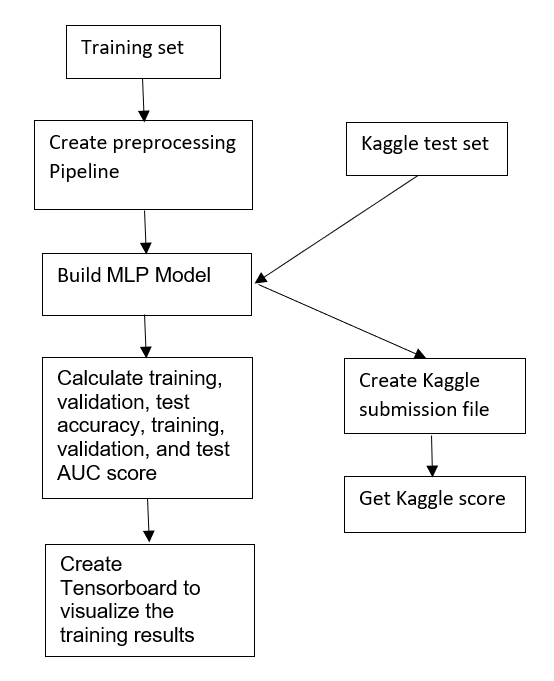

## Leakage detection

In phase 2, we filled missing value of 4 features 'prev_loans', 'dwn_pymt_pct', 'DAYS_LATE_PAYMENT', 'AMT_LATE_PAYMENT' with 0 right after loading data from file 'app_train_joined.csv'. Then we splited the data in to traing, validation and test sets.

After reviewing the pipeline steps taken in phase 2, we have addressed Data Leakage concerns. Mainly in the below areas:

In phase 3, we splited the data right after loading file 'app_train_joined.csv' to be safe.

## Preprocessing Pipeline

Here is our pipeline diagram:

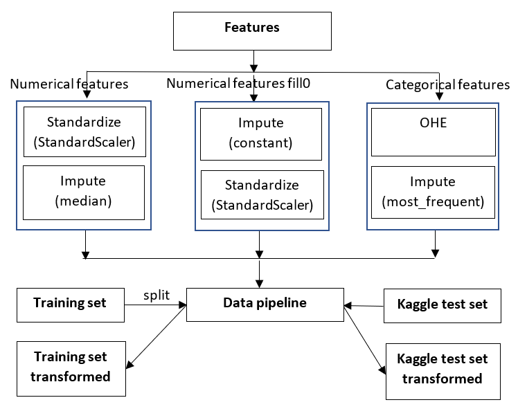

There are 47 raw features in our training set.

**Numerical features:** We use StanardScaler to scale these features and impute the missing value with median.

```
numerical_selected_features = ['CNT_CHILDREN', 'AMT_INCOME_TOTAL', 'AMT_CREDIT', 'AMT_ANNUITY', 'AMT_GOODS_PRICE', 'REGION_POPULATION_RELATIVE', 'DAYS_REGISTRATION', 'DAYS_ID_PUBLISH', 'OWN_CAR_AGE', 'CNT_FAM_MEMBERS',
 'EXT_SOURCE_1', 'EXT_SOURCE_2', 'EXT_SOURCE_3', 'OBS_30_CNT_SOCIAL_CIRCLE', 'DEF_30_CNT_SOCIAL_CIRCLE', 'DAYS_LAST_PHONE_CHANGE', 'work_history', 'inc_loan_ratio']
```

**The numerical features fill0:** We use StanardScaler to scale these features and impute the missing value with 0.

```
numerical_features_fill0 = ['prev_loans','dwn_pymt_pct','DAYS_LATE_PAYMENT','AMT_LATE_PAYMENT']
```

**The categorical features:** We use OneHotEncoder to scale these features and impute the missing value with 'most_frequent' strategy.

```
categorical_selected_features = ['NAME_CONTRACT_TYPE', 'CODE_GENDER', 'FLAG_OWN_CAR', 'FLAG_OWN_REALTY', 'NAME_TYPE_SUITE', 'NAME_INCOME_TYPE', 'NAME_EDUCATION_TYPE', 'NAME_FAMILY_STATUS', 'NAME_HOUSING_TYPE', 'FLAG_MOBIL', 'FLAG_EMP_PHONE', 'FLAG_WORK_PHONE', 'FLAG_CONT_MOBILE', 'FLAG_PHONE', 'FLAG_EMAIL', 'OCCUPATION_TYPE' ,'REGION_RATING_CLIENT', 'REGION_RATING_CLIENT_W_CITY', 'REG_REGION_NOT_LIVE_REGION', 'REG_REGION_NOT_WORK_REGION', 'LIVE_REGION_NOT_WORK_REGION', 'REG_CITY_NOT_LIVE_CITY', 'REG_CITY_NOT_WORK_CITY', 'LIVE_CITY_NOT_WORK_CITY', 'ORGANIZATION_TYPE']
```

## MLP Modeling

We use CrossEntropyLoss for this model. More detail about this loss function can be seen [here](https://pytorch.org/docs/stable/generated/torch.nn.CrossEntropyLoss.html)

Our Multilayer Perception model has one hidden layer with 512 neurons. The input layer has 168 features (after transforming), and the output layer has 2 outputs, 0 and 1.

Here is the MLP modeling architecture:

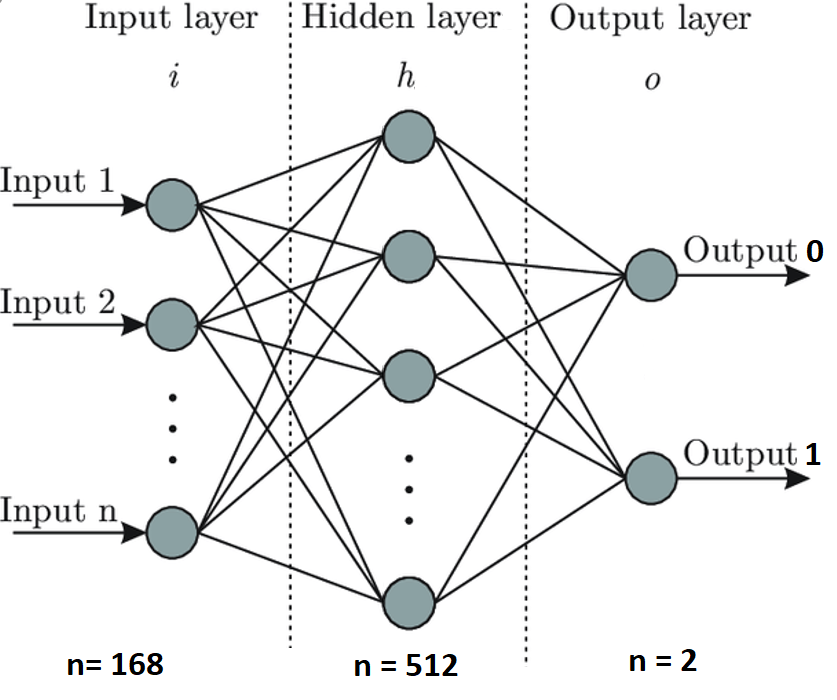

```
model = torch.nn.Sequential(
    torch.nn.Linear(168, 512),
    nn.ReLU(),
    nn.Linear(in_features=512, out_features=2)

)

loss_fn = torch.nn.CrossEntropyLoss()
optimizer = optim.SGD(model.parameters(), lr=0.01)
```

## Evaluation metric

**Area Under the Curve-Receiver Operating Characteristics (AUC-ROC) score** will be used to evaluate the accuracy of various logistic regression models (based on varying hyperparameters and thresholds). The AUC score represents the area under the ROC graph. The ROC graph represents a plot of the True Positive Rate (TPR) versus the False Positive Rate (FPR) – where each point on the graph represents a different logistic regression model. The higher the AUC-ROC score, the better. TPR and FPR are defined in equations 1 and 2, respectively.

**Equation 1:**

*True Positive Rate, TPR = True Positives / (True Positives + False Negatives)*

Where:

```
True Positives = samples accurately classified as class 1 (class 1 = will default on loan)

False Negatives = samples incorrectly classified as class 0 (class 0 = will not default on loan)
```

**Equation 2:**

*False Positive Rate, FPR = False Positives / (True Negatives + False Positives)*

Where:

```
False Positives = samples incorrectly classified as class 1

True Negatives = samples accurately classified as class 0
```

## Results

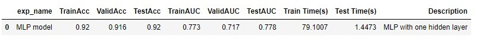

**Tensorboard result:**

[figure not shown]

## Kaggle Submission

[figure not shown]

## Discussion

**We have a Multi-layer Perception model** that has one hidden layer with 512 neurons. The input layer has 168 features, and the output layer has 2 outputs, 0 and 1.

The training AUC and test AUC of our model in phase 3 are 0.773 and 0.778. These results are better than the results of our best model (LightGBM) in phase 2 in overall. The traing AUC of the LightGBM model in phase 2 was 0.826, bit the test AUC was 0.76 which is far from 0.826.

**The tensorboard results** demonstrates that the training accuracy of the MLP model is from 0.919 to 0.92 which is similar to models in phase 1 and 2.

After 20 eporchs, the training loss descreases gradually from 0.259 to 0.246.

**Kaggle Submission:**

We applied the MLP model to create Kaggle submission file and got public score at 0.74082 and private scores at 0.73345. Our Kaggle scores in this phase are highest among 3 phases.

**Overall:**

With all our experiments we have created, MLP model has the highest test AUC in our notebook (0.778) as well as in Kaggle (public score at 0.74082 and private scores at 0.73345).

## Conclusion

Our main aim for this project is to efficiently provide financial needs to customers with little or no credit history.

In the third phase, we have addressed the data leakage concerns on the machine learning pipeline and found this risk is minimized as the available data is split into training, test, and validation sets, we build a multi-layer perceptron model which gave us a test AUC about 77.8%.

The model was implemented with one hidden layer comprising 512 neurons. Using this MLP model we see that our Test AUC score has increased from 0.76 to 0.778.

Also we have implemented tensor board to visualize the modeling pipelines to view the training performance real time using PyTorch.

The idea is to improve the accuracy of our models, and Kaggle submission public score has increased from 0.725 to 0.7408.

For future scope, we can further do feature Engineering on other tables, expand the grid search and build MLP with more hidden layers, and experiment with different activation functions.